# Results: Program 1

The MEANS Procedure

| Variable | Label | N | Mean | Std Dev | Minimum | Maximum |
| --- | --- | --- | --- | --- | --- | --- |
| Nabiz Kan_Basinci_Sistolik Kan_Basinci_Diyastolik Ders_Saatleri Proje_Saatleri | Nabiz Kan_Basinci_Sistolik Kan_Basinci_Diyastolik Ders_Saatleri Proje_Saatleri | 1000 1000 1000 1000 1000 | 70.1018631 119.8353798 79.8547558 30.2270372 14.8873684 | 9.5446629 14.6043072 9.6416987 10.3410603 4.8886235 | 50.0000000 90.0000000 60.0000000 5.0000000 0 | 99.6501035 165.9292045 107.6597961 60.0000000 32.7203251 |

The FREQ Procedure

| Uyku_Kalitesi | Uyku_Kalitesi Frequency | Uyku_Kalitesi Percent | Uyku_Kalitesi Cumulative Frequency | Uyku_Kalitesi Cumulative Percent |
| --- | --- | --- | --- | --- |
| 1 | 210 | 21.00 | 210 | 21.00 |
| 2 | 317 | 31.70 | 527 | 52.70 |
| 3 | 473 | 47.30 | 1000 | 100.00 |

| Ruh_Hali | Ruh_Hali Frequency | Ruh_Hali Percent | Ruh_Hali Cumulative Frequency | Ruh_Hali Cumulative Percent |
| --- | --- | --- | --- | --- |
| 1 | 186 | 18.60 | 186 | 18.60 |
| 2 | 415 | 41.50 | 601 | 60.10 |
| 3 | 399 | 39.90 | 1000 | 100.00 |

The DISCRIM Procedure

| Total Sample Size | 1000 | DF Total | 999 |
| --- | --- | --- | --- |
| Variables | 5 | DF Within Classes | 997 |
| Classes | 3 | DF Between Classes | 2 |

| Number of Observations Read | 1000 |
| --- | --- |
| Number of Observations Used | 1000 |

| Class Level Information Uyku_Kalitesi | Class Level Information Variable Name | Class Level Information Frequency | Class Level Information Weight | Class Level Information Proportion | Class Level Information Prior Probability |
| --- | --- | --- | --- | --- | --- |
| 1 | 1 | 210 | 210.0000 | 0.210000 | 0.333333 |
| 2 | 2 | 317 | 317.0000 | 0.317000 | 0.333333 |
| 3 | 3 | 473 | 473.0000 | 0.473000 | 0.333333 |

| Within Covariance Matrix Information Uyku_Kalitesi | Within Covariance Matrix Information Covariance Matrix Rank | Within Covariance Matrix Information Natural Log of the Determinant of the Covariance Matrix |
| --- | --- | --- |
| 1 | 5 | 22.47842 |
| 2 | 5 | 22.33528 |
| 3 | 5 | 22.02740 |
| Pooled | 5 | 22.24486 |

The DISCRIM Procedure

Test of Homogeneity of Within Covariance Matrices

| Chi-Square | DF | Pr > ChiSq |
| --- | --- | --- |
| 25.048879 | 30 | 0.7227 |

Since the Chi-Square value is not significant at the 0.1 level, a pooled covariance matrix will be used in the discriminant function.  
Reference: Morrison, D.F. (1976) Multivariate Statistical Methods p252.

The DISCRIM Procedure

| Generalized Squared Distance to Uyku_Kalitesi From Uyku_Kalitesi | Generalized Squared Distance to Uyku_Kalitesi 1 | Generalized Squared Distance to Uyku_Kalitesi 2 | Generalized Squared Distance to Uyku_Kalitesi 3 |
| --- | --- | --- | --- |
| 1 | 0 | 0.06911 | 0.03942 |
| 2 | 0.06911 | 0 | 0.01929 |
| 3 | 0.03942 | 0.01929 | 0 |

| Linear Discriminant Function for Uyku_Kalitesi Variable | Linear Discriminant Function for Uyku_Kalitesi Label | Linear Discriminant Function for Uyku_Kalitesi 1 | Linear Discriminant Function for Uyku_Kalitesi 2 | Linear Discriminant Function for Uyku_Kalitesi 3 |
| --- | --- | --- | --- | --- |
| Constant |  | -103.45777 | -105.49874 | -105.04949 |
| Nabiz | Nabiz | 0.76704 | 0.78160 | 0.77377 |
| Kan_Basinci_Sistolik | Kan_Basinci_Sistolik | 0.54892 | 0.55187 | 0.55286 |
| Kan_Basinci_Diyastolik | Kan_Basinci_Diyastolik | 0.87256 | 0.87007 | 0.87439 |
| Ders_Saatleri | Ders_Saatleri | 0.27698 | 0.28586 | 0.27589 |
| Proje_Saatleri | Proje_Saatleri | 0.71829 | 0.75903 | 0.75508 |

The DISCRIM Procedure

Classification Summary for Calibration Data: WORK.OGRENCI_DATA

Resubstitution Summary using Linear Discriminant Function

| Number of Observations and Percent Classified into Uyku_Kalitesi From Uyku_Kalitesi | Number of Observations and Percent Classified into Uyku_Kalitesi 1 | Number of Observations and Percent Classified into Uyku_Kalitesi 2 | Number of Observations and Percent Classified into Uyku_Kalitesi 3 | Number of Observations and Percent Classified into Uyku_Kalitesi Total |
| --- | --- | --- | --- | --- |
| 1 | 99 47.14 | 70 33.33 | 41 19.52 | 210 100.00 |
| 2 | 123 38.80 | 127 40.06 | 67 21.14 | 317 100.00 |
| 3 | 183 38.69 | 173 36.58 | 117 24.74 | 473 100.00 |
| Total | 405 40.50 | 370 37.00 | 225 22.50 | 1000 100.00 |
| Priors | 0.33333 | 0.33333 | 0.33333 |  |

| Error Count Estimates for Uyku_Kalitesi | Error Count Estimates for Uyku_Kalitesi 1 | Error Count Estimates for Uyku_Kalitesi 2 | Error Count Estimates for Uyku_Kalitesi 3 | Error Count Estimates for Uyku_Kalitesi Total |
| --- | --- | --- | --- | --- |
| Rate | 0.5286 | 0.5994 | 0.7526 | 0.6269 |
| Priors | 0.3333 | 0.3333 | 0.3333 |  |

The GLM Procedure

| Class Level Information Class | Class Level Information Levels | Class Level Information Values |
| --- | --- | --- |
| Uyku_Kalitesi | 3 | 1 2 3 |

| Number of Observations Read | 1000 |
| --- | --- |
| Number of Observations Used | 1000 |

The GLM Procedure

Dependent Variable: Nabiz Nabiz

| Source | DF | Sum of Squares | Mean Square | F Value | Pr > F |
| --- | --- | --- | --- | --- | --- |
| Model | 2 | 248.52258 | 124.26129 | 1.36 | 0.2559 |
| Error | 997 | 90760.96731 | 91.03407 |  |  |
| Corrected Total | 999 | 91009.48989 |  |  |  |

| R-Square | Coeff Var | Root MSE | Nabiz Mean |
| --- | --- | --- | --- |
| 0.002731 | 13.61045 | 9.541178 | 70.10186 |

| Source | DF | Type III SS | Mean Square | F Value | Pr > F |
| --- | --- | --- | --- | --- | --- |
| Uyku_Kalitesi | 2 | 248.5225760 | 124.2612880 | 1.36 | 0.2559 |

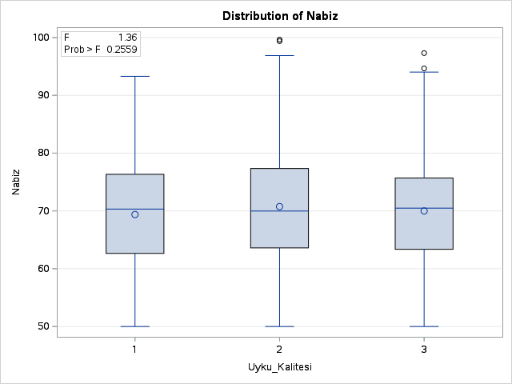

The GLM Procedure

Dependent Variable: Kan_Basinci_Sistolik Kan_Basinci_Sistolik

| Source | DF | Sum of Squares | Mean Square | F Value | Pr > F |
| --- | --- | --- | --- | --- | --- |
| Model | 2 | 86.7531 | 43.3766 | 0.20 | 0.8163 |
| Error | 997 | 212985.7512 | 213.6266 |  |  |
| Corrected Total | 999 | 213072.5044 |  |  |  |

| R-Square | Coeff Var | Root MSE | Kan_Basinci_Sistolik Mean |
| --- | --- | --- | --- |
| 0.000407 | 12.19671 | 14.61597 | 119.8354 |

| Source | DF | Type III SS | Mean Square | F Value | Pr > F |
| --- | --- | --- | --- | --- | --- |
| Uyku_Kalitesi | 2 | 86.75313610 | 43.37656805 | 0.20 | 0.8163 |

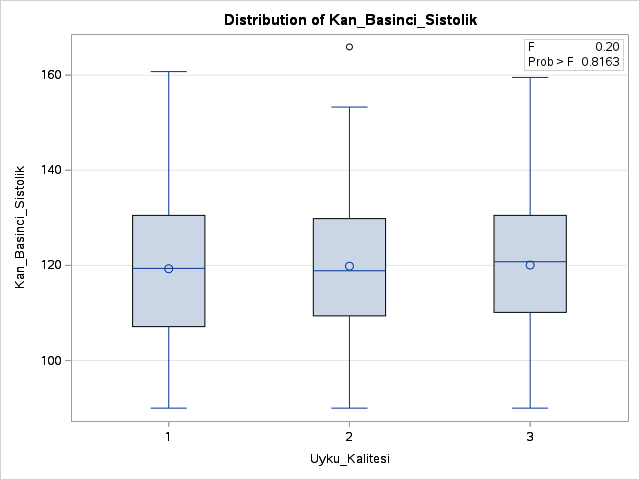

The GLM Procedure

Dependent Variable: Kan_Basinci_Diyastolik Kan_Basinci_Diyastolik

| Source | DF | Sum of Squares | Mean Square | F Value | Pr > F |
| --- | --- | --- | --- | --- | --- |
| Model | 2 | 37.16510 | 18.58255 | 0.20 | 0.8191 |
| Error | 997 | 92832.22648 | 93.11156 |  |  |
| Corrected Total | 999 | 92869.39159 |  |  |  |

| R-Square | Coeff Var | Root MSE | Kan_Basinci_Diyastolik Mean |
| --- | --- | --- | --- |
| 0.000400 | 12.08373 | 9.649433 | 79.85476 |

| Source | DF | Type III SS | Mean Square | F Value | Pr > F |
| --- | --- | --- | --- | --- | --- |
| Uyku_Kalitesi | 2 | 37.16510475 | 18.58255238 | 0.20 | 0.8191 |

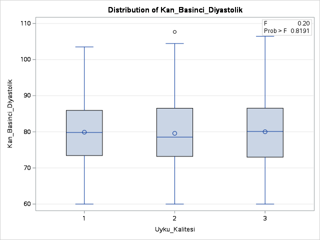

The GLM Procedure

Dependent Variable: Ders_Saatleri Ders_Saatleri

| Source | DF | Sum of Squares | Mean Square | F Value | Pr > F |
| --- | --- | --- | --- | --- | --- |
| Model | 2 | 238.6021 | 119.3010 | 1.12 | 0.3280 |
| Error | 997 | 106591.9890 | 106.9127 |  |  |
| Corrected Total | 999 | 106830.5911 |  |  |  |

| R-Square | Coeff Var | Root MSE | Ders_Saatleri Mean |
| --- | --- | --- | --- |
| 0.002233 | 34.20733 | 10.33986 | 30.22704 |

| Source | DF | Type III SS | Mean Square | F Value | Pr > F |
| --- | --- | --- | --- | --- | --- |
| Uyku_Kalitesi | 2 | 238.6020936 | 119.3010468 | 1.12 | 0.3280 |

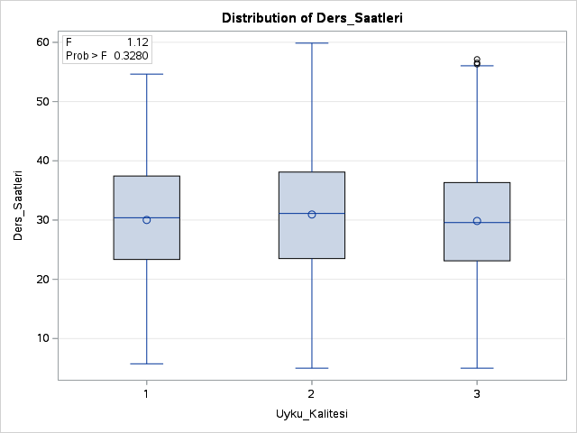

The GLM Procedure

Dependent Variable: Proje_Saatleri Proje_Saatleri

| Source | DF | Sum of Squares | Mean Square | F Value | Pr > F |
| --- | --- | --- | --- | --- | --- |
| Model | 2 | 135.33287 | 67.66644 | 2.84 | 0.0588 |
| Error | 997 | 23739.40839 | 23.81084 |  |  |
| Corrected Total | 999 | 23874.74126 |  |  |  |

| R-Square | Coeff Var | Root MSE | Proje_Saatleri Mean |
| --- | --- | --- | --- |
| 0.005668 | 32.77702 | 4.879635 | 14.88737 |

| Source | DF | Type III SS | Mean Square | F Value | Pr > F |
| --- | --- | --- | --- | --- | --- |
| Uyku_Kalitesi | 2 | 135.3328717 | 67.6664359 | 2.84 | 0.0588 |

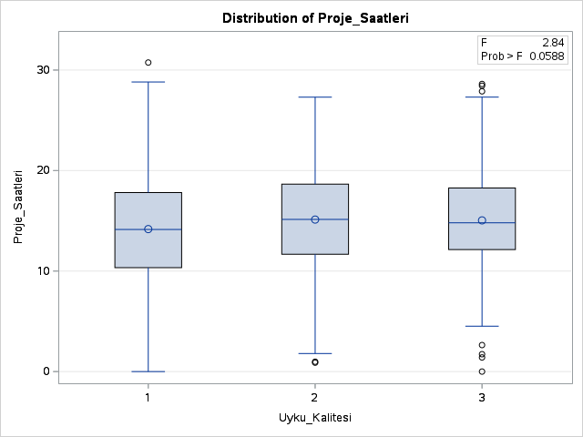

The GLM Procedure

Multivariate Analysis of Variance

| E = Error SSCP Matrix | E = Error SSCP Matrix Nabiz | E = Error SSCP Matrix Kan_Basinci_Sistolik | E = Error SSCP Matrix Kan_Basinci_Diyastolik | E = Error SSCP Matrix Ders_Saatleri | E = Error SSCP Matrix Proje_Saatleri |
| --- | --- | --- | --- | --- | --- |
| Nabiz | 90760.967311 | 1390.8274859 | -2616.888736 | 3957.7772704 | -30.37363067 |
| Kan_Basinci_Sistolik | 1390.8274859 | 212985.75123 | 3232.0996508 | -696.7442806 | -2318.972466 |
| Kan_Basinci_Diyastolik | -2616.888736 | 3232.0996508 | 92832.226482 | -886.2896087 | -1204.168384 |
| Ders_Saatleri | 3957.7772704 | -696.7442806 | -886.2896087 | 106591.98898 | -2059.154142 |
| Proje_Saatleri | -30.37363067 | -2318.972466 | -1204.168384 | -2059.154142 | 23739.408392 |

| Partial Correlation Coefficients from the Error SSCP Matrix / Prob > \|r\| DF = 997 | Partial Correlation Coefficients from the Error SSCP Matrix / Prob > \|r\| Nabiz | Partial Correlation Coefficients from the Error SSCP Matrix / Prob > \|r\| Kan_Basinci_Sistolik | Partial Correlation Coefficients from the Error SSCP Matrix / Prob > \|r\| Kan_Basinci_Diyastolik | Partial Correlation Coefficients from the Error SSCP Matrix / Prob > \|r\| Ders_Saatleri | Partial Correlation Coefficients from the Error SSCP Matrix / Prob > \|r\| Proje_Saatleri |
| --- | --- | --- | --- | --- | --- |
| Nabiz | 1.000000 | 0.010003 0.7523 | -0.028509 0.3683 | 0.040238 0.2041 | -0.000654 0.9835 |
| Kan_Basinci_Sistolik | 0.010003 0.7523 | 1.000000 | 0.022986 0.4682 | -0.004624 0.8840 | -0.032613 0.3034 |
| Kan_Basinci_Diyastolik | -0.028509 0.3683 | 0.022986 0.4682 | 1.000000 | -0.008910 0.7786 | -0.025651 0.4183 |
| Ders_Saatleri | 0.040238 0.2041 | -0.004624 0.8840 | -0.008910 0.7786 | 1.000000 | -0.040935 0.1963 |
| Proje_Saatleri | -0.000654 0.9835 | -0.032613 0.3034 | -0.025651 0.4183 | -0.040935 0.1963 | 1.000000 |

The GLM Procedure

Multivariate Analysis of Variance

| H = Type III SSCP Matrix for Uyku_Kalitesi | H = Type III SSCP Matrix for Uyku_Kalitesi Nabiz | H = Type III SSCP Matrix for Uyku_Kalitesi Kan_Basinci_Sistolik | H = Type III SSCP Matrix for Uyku_Kalitesi Kan_Basinci_Diyastolik | H = Type III SSCP Matrix for Uyku_Kalitesi Ders_Saatleri | H = Type III SSCP Matrix for Uyku_Kalitesi Proje_Saatleri |
| --- | --- | --- | --- | --- | --- |
| Nabiz | 248.52257605 | 69.535858011 | -71.80475177 | 198.70558406 | 147.91884568 |
| Kan_Basinci_Sistolik | 69.535858011 | 86.753136104 | 13.14989133 | -17.65196557 | 97.802337369 |
| Kan_Basinci_Diyastolik | -71.80475177 | 13.14989133 | 37.165104755 | -93.5918468 | -14.87211958 |
| Ders_Saatleri | 198.70558406 | -17.65196557 | -93.5918468 | 238.60209361 | 56.863516246 |
| Proje_Saatleri | 147.91884568 | 97.802337369 | -14.87211958 | 56.863516246 | 135.33287172 |

| Characteristic Roots and Vectors of: E Inverse * H, where H = Type III SSCP Matrix for Uyku_Kalitesi E = Error SSCP Matrix Characteristic Root | Characteristic Roots and Vectors of: E Inverse * H, where H = Type III SSCP Matrix for Uyku_Kalitesi E = Error SSCP Matrix Percent | Characteristic Roots and Vectors of: E Inverse * H, where H = Type III SSCP Matrix for Uyku_Kalitesi E = Error SSCP Matrix Characteristic Vector V'EV=1 Nabiz | Characteristic Roots and Vectors of: E Inverse * H, where H = Type III SSCP Matrix for Uyku_Kalitesi E = Error SSCP Matrix Characteristic Vector V'EV=1 Kan_Basinci_Sistolik | Characteristic Roots and Vectors of: E Inverse * H, where H = Type III SSCP Matrix for Uyku_Kalitesi E = Error SSCP Matrix Characteristic Vector V'EV=1 Kan_Basinci_Diyastolik | Characteristic Roots and Vectors of: E Inverse * H, where H = Type III SSCP Matrix for Uyku_Kalitesi E = Error SSCP Matrix Characteristic Vector V'EV=1 Ders_Saatleri | Characteristic Roots and Vectors of: E Inverse * H, where H = Type III SSCP Matrix for Uyku_Kalitesi E = Error SSCP Matrix Characteristic Vector V'EV=1 Proje_Saatleri |
| --- | --- | --- | --- | --- | --- | --- |
| 0.00880431 | 76.94 | 0.00171135 | 0.00038510 | -0.00024853 | 0.00096684 | 0.00505851 |
| 0.00263932 | 23.06 | -0.00090389 | 0.00060830 | 0.00106969 | -0.00214492 | 0.00298158 |
| 0.00000000 | 0.00 | -0.00004096 | 0.00204486 | -0.00027319 | 0.00047441 | -0.00166236 |
| 0.00000000 | 0.00 | 0.00058501 | -0.00005098 | 0.00308412 | 0.00086859 | -0.00062862 |
| 0.00000000 | 0.00 | -0.00263747 | 0.00002803 | 0.00004292 | 0.00170254 | 0.00215185 |

| MANOVA Test Criteria and F Approximations for the Hypothesis of No Overall Uyku_Kalitesi Effect H = Type III SSCP Matrix for Uyku_Kalitesi E = Error SSCP Matrix S=2 M=1 N=495.5 Statistic | MANOVA Test Criteria and F Approximations for the Hypothesis of No Overall Uyku_Kalitesi Effect H = Type III SSCP Matrix for Uyku_Kalitesi E = Error SSCP Matrix S=2 M=1 N=495.5 Value | MANOVA Test Criteria and F Approximations for the Hypothesis of No Overall Uyku_Kalitesi Effect H = Type III SSCP Matrix for Uyku_Kalitesi E = Error SSCP Matrix S=2 M=1 N=495.5 F Value | MANOVA Test Criteria and F Approximations for the Hypothesis of No Overall Uyku_Kalitesi Effect H = Type III SSCP Matrix for Uyku_Kalitesi E = Error SSCP Matrix S=2 M=1 N=495.5 Num DF | MANOVA Test Criteria and F Approximations for the Hypothesis of No Overall Uyku_Kalitesi Effect H = Type III SSCP Matrix for Uyku_Kalitesi E = Error SSCP Matrix S=2 M=1 N=495.5 Den DF | MANOVA Test Criteria and F Approximations for the Hypothesis of No Overall Uyku_Kalitesi Effect H = Type III SSCP Matrix for Uyku_Kalitesi E = Error SSCP Matrix S=2 M=1 N=495.5 Pr > F |
| --- | --- | --- | --- | --- | --- |
| Wilks' Lambda | 0.98866313 | 1.14 | 10 | 1986 | 0.3313 |
| Pillai's Trace | 0.01135985 | 1.14 | 10 | 1988 | 0.3312 |
| Hotelling-Lawley Trace | 0.01144364 | 1.14 | 10 | 1486.8 | 0.3314 |
| Roy's Greatest Root | 0.00880431 | 1.75 | 5 | 994 | 0.1205 |

NOTE: F Statistic for Roy's Greatest Root is an upper bound.  
NOTE: F Statistic for Wilks' Lambda is exact.

The GLM Procedure

| Levene's Test for Homogeneity of Nabiz Variance ANOVA of Squared Deviations from Group Means Source | Levene's Test for Homogeneity of Nabiz Variance ANOVA of Squared Deviations from Group Means DF | Levene's Test for Homogeneity of Nabiz Variance ANOVA of Squared Deviations from Group Means Sum of Squares | Levene's Test for Homogeneity of Nabiz Variance ANOVA of Squared Deviations from Group Means Mean Square | Levene's Test for Homogeneity of Nabiz Variance ANOVA of Squared Deviations from Group Means F Value | Levene's Test for Homogeneity of Nabiz Variance ANOVA of Squared Deviations from Group Means Pr > F |
| --- | --- | --- | --- | --- | --- |
| Uyku_Kalitesi | 2 | 107810 | 53904.9 | 3.64 | 0.0265 |
| Error | 997 | 14748944 | 14793.3 |  |  |

| Levene's Test for Homogeneity of Kan_Basinci_Sistolik Variance ANOVA of Squared Deviations from Group Means Source | Levene's Test for Homogeneity of Kan_Basinci_Sistolik Variance ANOVA of Squared Deviations from Group Means DF | Levene's Test for Homogeneity of Kan_Basinci_Sistolik Variance ANOVA of Squared Deviations from Group Means Sum of Squares | Levene's Test for Homogeneity of Kan_Basinci_Sistolik Variance ANOVA of Squared Deviations from Group Means Mean Square | Levene's Test for Homogeneity of Kan_Basinci_Sistolik Variance ANOVA of Squared Deviations from Group Means F Value | Levene's Test for Homogeneity of Kan_Basinci_Sistolik Variance ANOVA of Squared Deviations from Group Means Pr > F |
| --- | --- | --- | --- | --- | --- |
| Uyku_Kalitesi | 2 | 690171 | 345086 | 4.94 | 0.0073 |
| Error | 997 | 69607718 | 69817.2 |  |  |

| Levene's Test for Homogeneity of Kan_Basinci_Diyastolik Variance ANOVA of Squared Deviations from Group Means Source | Levene's Test for Homogeneity of Kan_Basinci_Diyastolik Variance ANOVA of Squared Deviations from Group Means DF | Levene's Test for Homogeneity of Kan_Basinci_Diyastolik Variance ANOVA of Squared Deviations from Group Means Sum of Squares | Levene's Test for Homogeneity of Kan_Basinci_Diyastolik Variance ANOVA of Squared Deviations from Group Means Mean Square | Levene's Test for Homogeneity of Kan_Basinci_Diyastolik Variance ANOVA of Squared Deviations from Group Means F Value | Levene's Test for Homogeneity of Kan_Basinci_Diyastolik Variance ANOVA of Squared Deviations from Group Means Pr > F |
| --- | --- | --- | --- | --- | --- |
| Uyku_Kalitesi | 2 | 23218.4 | 11609.2 | 0.83 | 0.4358 |
| Error | 997 | 13923787 | 13965.7 |  |  |

| Levene's Test for Homogeneity of Ders_Saatleri Variance ANOVA of Squared Deviations from Group Means Source | Levene's Test for Homogeneity of Ders_Saatleri Variance ANOVA of Squared Deviations from Group Means DF | Levene's Test for Homogeneity of Ders_Saatleri Variance ANOVA of Squared Deviations from Group Means Sum of Squares | Levene's Test for Homogeneity of Ders_Saatleri Variance ANOVA of Squared Deviations from Group Means Mean Square | Levene's Test for Homogeneity of Ders_Saatleri Variance ANOVA of Squared Deviations from Group Means F Value | Levene's Test for Homogeneity of Ders_Saatleri Variance ANOVA of Squared Deviations from Group Means Pr > F |
| --- | --- | --- | --- | --- | --- |
| Uyku_Kalitesi | 2 | 30720.2 | 15360.1 | 0.73 | 0.4820 |
| Error | 997 | 20968906 | 21032.0 |  |  |

| Levene's Test for Homogeneity of Proje_Saatleri Variance ANOVA of Squared Deviations from Group Means Source | Levene's Test for Homogeneity of Proje_Saatleri Variance ANOVA of Squared Deviations from Group Means DF | Levene's Test for Homogeneity of Proje_Saatleri Variance ANOVA of Squared Deviations from Group Means Sum of Squares | Levene's Test for Homogeneity of Proje_Saatleri Variance ANOVA of Squared Deviations from Group Means Mean Square | Levene's Test for Homogeneity of Proje_Saatleri Variance ANOVA of Squared Deviations from Group Means F Value | Levene's Test for Homogeneity of Proje_Saatleri Variance ANOVA of Squared Deviations from Group Means Pr > F |
| --- | --- | --- | --- | --- | --- |
| Uyku_Kalitesi | 2 | 551.4 | 275.7 | 0.23 | 0.7962 |
| Error | 997 | 1205618 | 1209.2 |  |  |

The GLM Procedure

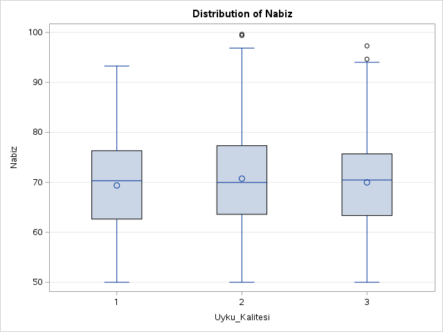

The GLM Procedure

Tukey's Studentized Range (HSD) Test for Nabiz

Note:This test controls the Type I experimentwise error rate.

| Alpha | 0.05 |
| --- | --- |
| Error Degrees of Freedom | 997 |
| Error Mean Square | 91.03407 |
| Critical Value of Studentized Range | 3.31946 |

| Comparisons significant at the 0.05 level are indicated by ***. Uyku_Kalitesi Comparison | Comparisons significant at the 0.05 level are indicated by ***. Difference Between Means | Comparisons significant at the 0.05 level are indicated by ***. Simultaneous 95% Confidence Limits | Comparisons significant at the 0.05 level are indicated by ***. Simultaneous 95% Confidence Limits | Comparisons significant at the 0.05 level are indicated by ***. |
| --- | --- | --- | --- | --- |
| 2 - 3 | 0.7617 | -0.8639 | 2.3872 |  |
| 2 - 1 | 1.3695 | -0.6231 | 3.3621 |  |
| 3 - 2 | -0.7617 | -2.3872 | 0.8639 |  |
| 3 - 1 | 0.6078 | -1.2493 | 2.4649 |  |
| 1 - 2 | -1.3695 | -3.3621 | 0.6231 |  |
| 1 - 3 | -0.6078 | -2.4649 | 1.2493 |  |

The GLM Procedure

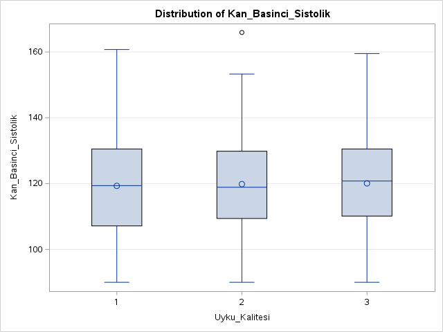

The GLM Procedure

Tukey's Studentized Range (HSD) Test for Kan_Basinci_Sistolik

Note:This test controls the Type I experimentwise error rate.

| Alpha | 0.05 |
| --- | --- |
| Error Degrees of Freedom | 997 |
| Error Mean Square | 213.6266 |
| Critical Value of Studentized Range | 3.31946 |

| Comparisons significant at the 0.05 level are indicated by ***. Uyku_Kalitesi Comparison | Comparisons significant at the 0.05 level are indicated by ***. Difference Between Means | Comparisons significant at the 0.05 level are indicated by ***. Simultaneous 95% Confidence Limits | Comparisons significant at the 0.05 level are indicated by ***. Simultaneous 95% Confidence Limits | Comparisons significant at the 0.05 level are indicated by ***. |
| --- | --- | --- | --- | --- |
| 3 - 2 | 0.2313 | -2.2589 | 2.7215 |  |
| 3 - 1 | 0.7723 | -2.0725 | 3.6171 |  |
| 2 - 3 | -0.2313 | -2.7215 | 2.2589 |  |
| 2 - 1 | 0.5410 | -2.5114 | 3.5935 |  |
| 1 - 3 | -0.7723 | -3.6171 | 2.0725 |  |
| 1 - 2 | -0.5410 | -3.5935 | 2.5114 |  |

The GLM Procedure

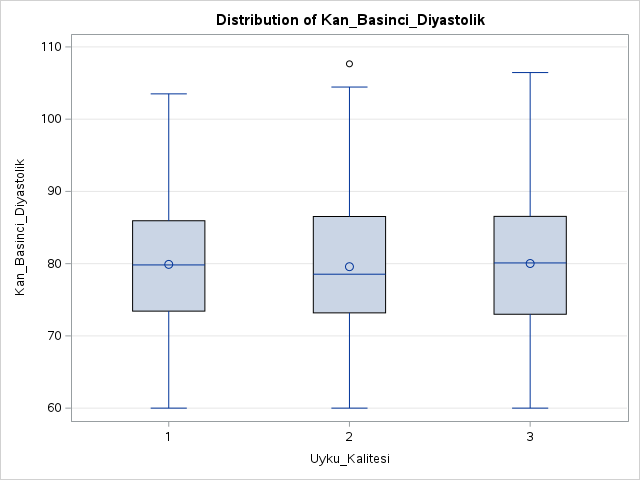

The GLM Procedure

Tukey's Studentized Range (HSD) Test for Kan_Basinci_Diyastolik

Note:This test controls the Type I experimentwise error rate.

| Alpha | 0.05 |
| --- | --- |
| Error Degrees of Freedom | 997 |
| Error Mean Square | 93.11156 |
| Critical Value of Studentized Range | 3.31946 |

| Comparisons significant at the 0.05 level are indicated by ***. Uyku_Kalitesi Comparison | Comparisons significant at the 0.05 level are indicated by ***. Difference Between Means | Comparisons significant at the 0.05 level are indicated by ***. Simultaneous 95% Confidence Limits | Comparisons significant at the 0.05 level are indicated by ***. Simultaneous 95% Confidence Limits | Comparisons significant at the 0.05 level are indicated by ***. |
| --- | --- | --- | --- | --- |
| 3 - 1 | 0.1219 | -1.7563 | 2.0000 |  |
| 3 - 2 | 0.4396 | -1.2045 | 2.0836 |  |
| 1 - 3 | -0.1219 | -2.0000 | 1.7563 |  |
| 1 - 2 | 0.3177 | -1.6975 | 2.3329 |  |
| 2 - 3 | -0.4396 | -2.0836 | 1.2045 |  |
| 2 - 1 | -0.3177 | -2.3329 | 1.6975 |  |

The GLM Procedure

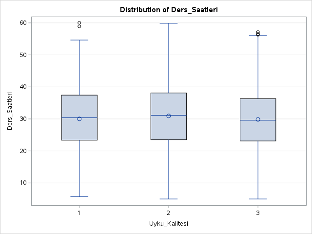

The GLM Procedure

Tukey's Studentized Range (HSD) Test for Ders_Saatleri

Note:This test controls the Type I experimentwise error rate.

| Alpha | 0.05 |
| --- | --- |
| Error Degrees of Freedom | 997 |
| Error Mean Square | 106.9127 |
| Critical Value of Studentized Range | 3.31946 |

| Comparisons significant at the 0.05 level are indicated by ***. Uyku_Kalitesi Comparison | Comparisons significant at the 0.05 level are indicated by ***. Difference Between Means | Comparisons significant at the 0.05 level are indicated by ***. Simultaneous 95% Confidence Limits | Comparisons significant at the 0.05 level are indicated by ***. Simultaneous 95% Confidence Limits | Comparisons significant at the 0.05 level are indicated by ***. |
| --- | --- | --- | --- | --- |
| 2 - 1 | 0.9231 | -1.2363 | 3.0825 |  |
| 2 - 3 | 1.0927 | -0.6690 | 2.8543 |  |
| 1 - 2 | -0.9231 | -3.0825 | 1.2363 |  |
| 1 - 3 | 0.1695 | -1.8430 | 2.1821 |  |
| 3 - 2 | -1.0927 | -2.8543 | 0.6690 |  |
| 3 - 1 | -0.1695 | -2.1821 | 1.8430 |  |

The GLM Procedure

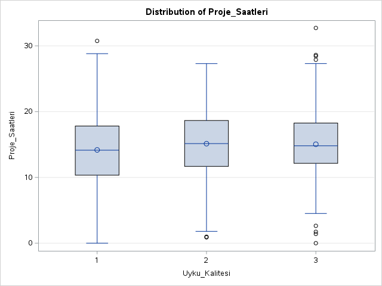

The GLM Procedure

Tukey's Studentized Range (HSD) Test for Proje_Saatleri

Note:This test controls the Type I experimentwise error rate.

| Alpha | 0.05 |
| --- | --- |
| Error Degrees of Freedom | 997 |
| Error Mean Square | 23.81084 |
| Critical Value of Studentized Range | 3.31946 |

| Comparisons significant at the 0.05 level are indicated by ***. Uyku_Kalitesi Comparison | Comparisons significant at the 0.05 level are indicated by ***. Difference Between Means | Comparisons significant at the 0.05 level are indicated by ***. Simultaneous 95% Confidence Limits | Comparisons significant at the 0.05 level are indicated by ***. Simultaneous 95% Confidence Limits | Comparisons significant at the 0.05 level are indicated by ***. |
| --- | --- | --- | --- | --- |
| 2 - 3 | 0.0808 | -0.7506 | 0.9122 |  |
| 2 - 1 | 0.9474 | -0.0717 | 1.9665 |  |
| 3 - 2 | -0.0808 | -0.9122 | 0.7506 |  |
| 3 - 1 | 0.8666 | -0.0831 | 1.8164 |  |
| 1 - 2 | -0.9474 | -1.9665 | 0.0717 |  |
| 1 - 3 | -0.8666 | -1.8164 | 0.0831 |  |

The GLM Procedure

| Class Level Information Class | Class Level Information Levels | Class Level Information Values |
| --- | --- | --- |
| Uyku_Kalitesi | 3 | 1 2 3 |
| Ruh_Hali | 3 | 1 2 3 |

| Number of Observations Read | 1000 |
| --- | --- |
| Number of Observations Used | 1000 |

The GLM Procedure

Dependent Variable: Nabiz Nabiz

| Source | DF | Sum of Squares | Mean Square | F Value | Pr > F |
| --- | --- | --- | --- | --- | --- |
| Model | 8 | 1183.54437 | 147.94305 | 1.63 | 0.1115 |
| Error | 991 | 89825.94551 | 90.64172 |  |  |
| Corrected Total | 999 | 91009.48989 |  |  |  |

| R-Square | Coeff Var | Root MSE | Nabiz Mean |
| --- | --- | --- | --- |
| 0.013005 | 13.58109 | 9.520595 | 70.10186 |

| Source | DF | Type III SS | Mean Square | F Value | Pr > F |
| --- | --- | --- | --- | --- | --- |
| Uyku_Kalitesi | 2 | 142.6546245 | 71.3273123 | 0.79 | 0.4555 |
| Ruh_Hali | 2 | 25.9355787 | 12.9677893 | 0.14 | 0.8667 |
| Uyku_Kalite*Ruh_Hali | 4 | 900.9032986 | 225.2258247 | 2.48 | 0.0422 |

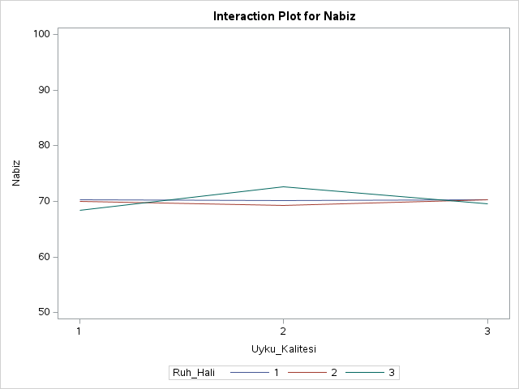

The GLM Procedure

Dependent Variable: Kan_Basinci_Sistolik Kan_Basinci_Sistolik

| Source | DF | Sum of Squares | Mean Square | F Value | Pr > F |
| --- | --- | --- | --- | --- | --- |
| Model | 8 | 986.0681 | 123.2585 | 0.58 | 0.7983 |
| Error | 991 | 212086.4362 | 214.0125 |  |  |
| Corrected Total | 999 | 213072.5044 |  |  |  |

| R-Square | Coeff Var | Root MSE | Kan_Basinci_Sistolik Mean |
| --- | --- | --- | --- |
| 0.004628 | 12.20772 | 14.62917 | 119.8354 |

| Source | DF | Type III SS | Mean Square | F Value | Pr > F |
| --- | --- | --- | --- | --- | --- |
| Uyku_Kalitesi | 2 | 36.0500328 | 18.0250164 | 0.08 | 0.9192 |
| Ruh_Hali | 2 | 312.7643825 | 156.3821912 | 0.73 | 0.4818 |
| Uyku_Kalite*Ruh_Hali | 4 | 330.3441984 | 82.5860496 | 0.39 | 0.8188 |

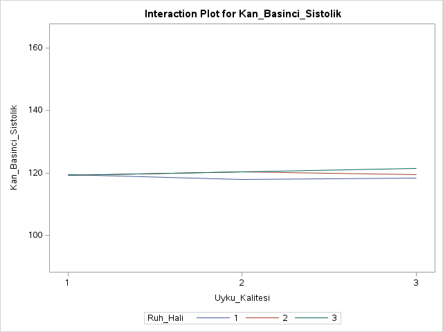

The GLM Procedure

Dependent Variable: Kan_Basinci_Diyastolik Kan_Basinci_Diyastolik

| Source | DF | Sum of Squares | Mean Square | F Value | Pr > F |
| --- | --- | --- | --- | --- | --- |
| Model | 8 | 186.11654 | 23.26457 | 0.25 | 0.9812 |
| Error | 991 | 92683.27505 | 93.52500 |  |  |
| Corrected Total | 999 | 92869.39159 |  |  |  |

| R-Square | Coeff Var | Root MSE | Kan_Basinci_Diyastolik Mean |
| --- | --- | --- | --- |
| 0.002004 | 12.11053 | 9.670832 | 79.85476 |

| Source | DF | Type III SS | Mean Square | F Value | Pr > F |
| --- | --- | --- | --- | --- | --- |
| Uyku_Kalitesi | 2 | 52.9463685 | 26.4731843 | 0.28 | 0.7535 |
| Ruh_Hali | 2 | 39.4087717 | 19.7043858 | 0.21 | 0.8101 |
| Uyku_Kalite*Ruh_Hali | 4 | 123.5135331 | 30.8783833 | 0.33 | 0.8578 |

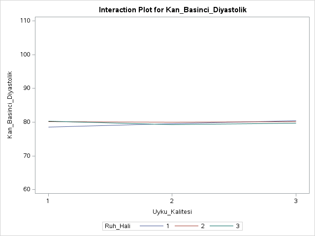

The GLM Procedure

Dependent Variable: Ders_Saatleri Ders_Saatleri

| Source | DF | Sum of Squares | Mean Square | F Value | Pr > F |
| --- | --- | --- | --- | --- | --- |
| Model | 8 | 781.5575 | 97.6947 | 0.91 | 0.5048 |
| Error | 991 | 106049.0336 | 107.0121 |  |  |
| Corrected Total | 999 | 106830.5911 |  |  |  |

| R-Square | Coeff Var | Root MSE | Ders_Saatleri Mean |
| --- | --- | --- | --- |
| 0.007316 | 34.22323 | 10.34467 | 30.22704 |

| Source | DF | Type III SS | Mean Square | F Value | Pr > F |
| --- | --- | --- | --- | --- | --- |
| Uyku_Kalitesi | 2 | 158.3995042 | 79.1997521 | 0.74 | 0.4773 |
| Ruh_Hali | 2 | 38.4518266 | 19.2259133 | 0.18 | 0.8356 |
| Uyku_Kalite*Ruh_Hali | 4 | 475.9990675 | 118.9997669 | 1.11 | 0.3494 |

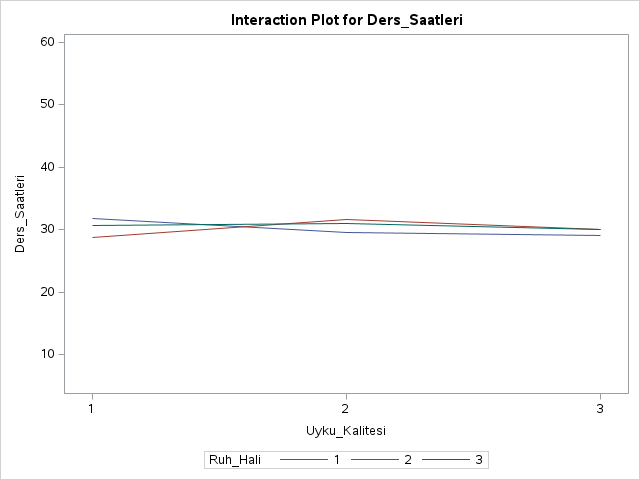

The GLM Procedure

Dependent Variable: Proje_Saatleri Proje_Saatleri

| Source | DF | Sum of Squares | Mean Square | F Value | Pr > F |
| --- | --- | --- | --- | --- | --- |
| Model | 8 | 313.07887 | 39.13486 | 1.65 | 0.1078 |
| Error | 991 | 23561.66239 | 23.77564 |  |  |
| Corrected Total | 999 | 23874.74126 |  |  |  |

| R-Square | Coeff Var | Root MSE | Proje_Saatleri Mean |
| --- | --- | --- | --- |
| 0.013113 | 32.75278 | 4.876027 | 14.88737 |

| Source | DF | Type III SS | Mean Square | F Value | Pr > F |
| --- | --- | --- | --- | --- | --- |
| Uyku_Kalitesi | 2 | 154.6781936 | 77.3390968 | 3.25 | 0.0391 |
| Ruh_Hali | 2 | 109.0286010 | 54.5143005 | 2.29 | 0.1015 |
| Uyku_Kalite*Ruh_Hali | 4 | 81.1310174 | 20.2827543 | 0.85 | 0.4917 |

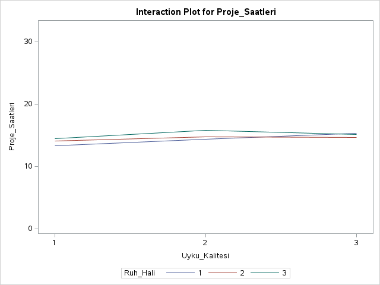

The GLM Procedure

Multivariate Analysis of Variance

| E = Error SSCP Matrix | E = Error SSCP Matrix Nabiz | E = Error SSCP Matrix Kan_Basinci_Sistolik | E = Error SSCP Matrix Kan_Basinci_Diyastolik | E = Error SSCP Matrix Ders_Saatleri | E = Error SSCP Matrix Proje_Saatleri |
| --- | --- | --- | --- | --- | --- |
| Nabiz | 89825.945513 | 1439.6277611 | -2426.871976 | 4123.8773178 | -193.9953904 |
| Kan_Basinci_Sistolik | 1439.6277611 | 212086.43625 | 3371.9375078 | -1050.308453 | -2440.477633 |
| Kan_Basinci_Diyastolik | -2426.871976 | 3371.9375078 | 92683.275046 | -792.468729 | -1210.856553 |
| Ders_Saatleri | 4123.8773178 | -1050.308453 | -792.468729 | 106049.03358 | -2032.534502 |
| Proje_Saatleri | -193.9953904 | -2440.477633 | -1210.856553 | -2032.534502 | 23561.662393 |

| Partial Correlation Coefficients from the Error SSCP Matrix / Prob > \|r\| DF = 991 | Partial Correlation Coefficients from the Error SSCP Matrix / Prob > \|r\| Nabiz | Partial Correlation Coefficients from the Error SSCP Matrix / Prob > \|r\| Kan_Basinci_Sistolik | Partial Correlation Coefficients from the Error SSCP Matrix / Prob > \|r\| Kan_Basinci_Diyastolik | Partial Correlation Coefficients from the Error SSCP Matrix / Prob > \|r\| Ders_Saatleri | Partial Correlation Coefficients from the Error SSCP Matrix / Prob > \|r\| Proje_Saatleri |
| --- | --- | --- | --- | --- | --- |
| Nabiz | 1.000000 | 0.010430 0.7428 | -0.026598 0.4027 | 0.042252 0.1836 | -0.004217 0.8945 |
| Kan_Basinci_Sistolik | 0.010430 0.7428 | 1.000000 | 0.024050 0.4493 | -0.007003 0.8256 | -0.034524 0.2773 |
| Kan_Basinci_Diyastolik | -0.026598 0.4027 | 0.024050 0.4493 | 1.000000 | -0.007993 0.8015 | -0.025911 0.4150 |
| Ders_Saatleri | 0.042252 0.1836 | -0.007003 0.8256 | -0.007993 0.8015 | 1.000000 | -0.040661 0.2007 |
| Proje_Saatleri | -0.004217 0.8945 | -0.034524 0.2773 | -0.025911 0.4150 | -0.040661 0.2007 | 1.000000 |

The GLM Procedure

Multivariate Analysis of Variance

| H = Type III SSCP Matrix for Uyku_Kalitesi | H = Type III SSCP Matrix for Uyku_Kalitesi Nabiz | H = Type III SSCP Matrix for Uyku_Kalitesi Kan_Basinci_Sistolik | H = Type III SSCP Matrix for Uyku_Kalitesi Kan_Basinci_Diyastolik | H = Type III SSCP Matrix for Uyku_Kalitesi Ders_Saatleri | H = Type III SSCP Matrix for Uyku_Kalitesi Proje_Saatleri |
| --- | --- | --- | --- | --- | --- |
| Nabiz | 142.65462454 | -5.07535018 | -28.74850935 | 73.445197782 | 93.501366945 |
| Kan_Basinci_Sistolik | -5.07535018 | 36.050032807 | 42.148791304 | -68.380598 | 54.552469869 |
| Kan_Basinci_Diyastolik | -28.74850935 | 42.148791304 | 52.946368537 | -90.2065938 | 47.518093597 |
| Ders_Saatleri | 73.445197782 | -68.380598 | -90.2065938 | 158.39950416 | -57.98388616 |
| Proje_Saatleri | 93.501366945 | 54.552469869 | 47.518093597 | -57.98388616 | 154.67819358 |

| Characteristic Roots and Vectors of: E Inverse * H, where H = Type III SSCP Matrix for Uyku_Kalitesi E = Error SSCP Matrix Characteristic Root | Characteristic Roots and Vectors of: E Inverse * H, where H = Type III SSCP Matrix for Uyku_Kalitesi E = Error SSCP Matrix Percent | Characteristic Roots and Vectors of: E Inverse * H, where H = Type III SSCP Matrix for Uyku_Kalitesi E = Error SSCP Matrix Characteristic Vector V'EV=1 Nabiz | Characteristic Roots and Vectors of: E Inverse * H, where H = Type III SSCP Matrix for Uyku_Kalitesi E = Error SSCP Matrix Characteristic Vector V'EV=1 Kan_Basinci_Sistolik | Characteristic Roots and Vectors of: E Inverse * H, where H = Type III SSCP Matrix for Uyku_Kalitesi E = Error SSCP Matrix Characteristic Vector V'EV=1 Kan_Basinci_Diyastolik | Characteristic Roots and Vectors of: E Inverse * H, where H = Type III SSCP Matrix for Uyku_Kalitesi E = Error SSCP Matrix Characteristic Vector V'EV=1 Ders_Saatleri | Characteristic Roots and Vectors of: E Inverse * H, where H = Type III SSCP Matrix for Uyku_Kalitesi E = Error SSCP Matrix Characteristic Vector V'EV=1 Proje_Saatleri |
| --- | --- | --- | --- | --- | --- | --- |
| 0.00772525 | 74.80 | 0.00098967 | 0.00028804 | 0.00056329 | -0.00042185 | 0.00603602 |
| 0.00260219 | 25.20 | 0.00191102 | -0.00035866 | -0.00122327 | 0.00207262 | 0.00014346 |
| 0.00000000 | 0.00 | 0.00020911 | 0.00212329 | -0.00028612 | 0.00042711 | -0.00062725 |
| 0.00000000 | 0.00 | 0.00074888 | -0.00005430 | 0.00298557 | 0.00096795 | -0.00098787 |
| 0.00000000 | 0.00 | -0.00243430 | 0.00003485 | 0.00004249 | 0.00196730 | 0.00218364 |

| MANOVA Test Criteria and F Approximations for the Hypothesis of No Overall Uyku_Kalitesi Effect H = Type III SSCP Matrix for Uyku_Kalitesi E = Error SSCP Matrix S=2 M=1 N=492.5 Statistic | MANOVA Test Criteria and F Approximations for the Hypothesis of No Overall Uyku_Kalitesi Effect H = Type III SSCP Matrix for Uyku_Kalitesi E = Error SSCP Matrix S=2 M=1 N=492.5 Value | MANOVA Test Criteria and F Approximations for the Hypothesis of No Overall Uyku_Kalitesi Effect H = Type III SSCP Matrix for Uyku_Kalitesi E = Error SSCP Matrix S=2 M=1 N=492.5 F Value | MANOVA Test Criteria and F Approximations for the Hypothesis of No Overall Uyku_Kalitesi Effect H = Type III SSCP Matrix for Uyku_Kalitesi E = Error SSCP Matrix S=2 M=1 N=492.5 Num DF | MANOVA Test Criteria and F Approximations for the Hypothesis of No Overall Uyku_Kalitesi Effect H = Type III SSCP Matrix for Uyku_Kalitesi E = Error SSCP Matrix S=2 M=1 N=492.5 Den DF | MANOVA Test Criteria and F Approximations for the Hypothesis of No Overall Uyku_Kalitesi Effect H = Type III SSCP Matrix for Uyku_Kalitesi E = Error SSCP Matrix S=2 M=1 N=492.5 Pr > F |
| --- | --- | --- | --- | --- | --- |
| Wilks' Lambda | 0.98975843 | 1.02 | 10 | 1974 | 0.4247 |
| Pillai's Trace | 0.01026147 | 1.02 | 10 | 1976 | 0.4244 |
| Hotelling-Lawley Trace | 0.01032745 | 1.02 | 10 | 1477.8 | 0.4249 |
| Roy's Greatest Root | 0.00772525 | 1.53 | 5 | 988 | 0.1788 |

NOTE: F Statistic for Roy's Greatest Root is an upper bound.  
NOTE: F Statistic for Wilks' Lambda is exact.

| H = Type III SSCP Matrix for Ruh_Hali | H = Type III SSCP Matrix for Ruh_Hali Nabiz | H = Type III SSCP Matrix for Ruh_Hali Kan_Basinci_Sistolik | H = Type III SSCP Matrix for Ruh_Hali Kan_Basinci_Diyastolik | H = Type III SSCP Matrix for Ruh_Hali Ders_Saatleri | H = Type III SSCP Matrix for Ruh_Hali Proje_Saatleri |
| --- | --- | --- | --- | --- | --- |
| Nabiz | 25.93557868 | -2.257597469 | -28.90287002 | 19.763837566 | 25.964439347 |
| Kan_Basinci_Sistolik | -2.257597469 | 312.76438249 | 49.952313189 | 83.785763168 | 158.84282904 |
| Kan_Basinci_Diyastolik | -28.90287002 | 49.952313189 | 39.408771678 | -9.048301238 | -4.485471138 |
| Ders_Saatleri | 19.763837566 | 83.785763168 | -9.048301238 | 38.451826554 | 63.857185101 |
| Proje_Saatleri | 25.964439347 | 158.84282904 | -4.485471138 | 63.857185101 | 109.028601 |

| Characteristic Roots and Vectors of: E Inverse * H, where H = Type III SSCP Matrix for Ruh_Hali E = Error SSCP Matrix Characteristic Root | Characteristic Roots and Vectors of: E Inverse * H, where H = Type III SSCP Matrix for Ruh_Hali E = Error SSCP Matrix Percent | Characteristic Roots and Vectors of: E Inverse * H, where H = Type III SSCP Matrix for Ruh_Hali E = Error SSCP Matrix Characteristic Vector V'EV=1 Nabiz | Characteristic Roots and Vectors of: E Inverse * H, where H = Type III SSCP Matrix for Ruh_Hali E = Error SSCP Matrix Characteristic Vector V'EV=1 Kan_Basinci_Sistolik | Characteristic Roots and Vectors of: E Inverse * H, where H = Type III SSCP Matrix for Ruh_Hali E = Error SSCP Matrix Characteristic Vector V'EV=1 Kan_Basinci_Diyastolik | Characteristic Roots and Vectors of: E Inverse * H, where H = Type III SSCP Matrix for Ruh_Hali E = Error SSCP Matrix Characteristic Vector V'EV=1 Ders_Saatleri | Characteristic Roots and Vectors of: E Inverse * H, where H = Type III SSCP Matrix for Ruh_Hali E = Error SSCP Matrix Characteristic Vector V'EV=1 Proje_Saatleri |
| --- | --- | --- | --- | --- | --- | --- |
| 0.00646114 | 87.12 | 0.00024550 | 0.00100476 | 0.00007290 | 0.00081245 | 0.00566854 |
| 0.00095500 | 12.88 | -0.00162316 | 0.00111279 | 0.00208898 | -0.00042066 | -0.00118198 |
| 0.00000000 | 0.00 | -0.00042263 | -0.00007331 | 0.00028640 | 0.00293665 | -0.00150074 |
| 0.00000000 | 0.00 | 0.00287766 | 0.00054661 | 0.00125057 | -0.00002646 | -0.00141470 |
| 0.00000000 | 0.00 | 0.00008564 | -0.00147382 | 0.00218995 | 0.00004102 | 0.00219288 |

| MANOVA Test Criteria and F Approximations for the Hypothesis of No Overall Ruh_Hali Effect H = Type III SSCP Matrix for Ruh_Hali E = Error SSCP Matrix S=2 M=1 N=492.5 Statistic | MANOVA Test Criteria and F Approximations for the Hypothesis of No Overall Ruh_Hali Effect H = Type III SSCP Matrix for Ruh_Hali E = Error SSCP Matrix S=2 M=1 N=492.5 Value | MANOVA Test Criteria and F Approximations for the Hypothesis of No Overall Ruh_Hali Effect H = Type III SSCP Matrix for Ruh_Hali E = Error SSCP Matrix S=2 M=1 N=492.5 F Value | MANOVA Test Criteria and F Approximations for the Hypothesis of No Overall Ruh_Hali Effect H = Type III SSCP Matrix for Ruh_Hali E = Error SSCP Matrix S=2 M=1 N=492.5 Num DF | MANOVA Test Criteria and F Approximations for the Hypothesis of No Overall Ruh_Hali Effect H = Type III SSCP Matrix for Ruh_Hali E = Error SSCP Matrix S=2 M=1 N=492.5 Den DF | MANOVA Test Criteria and F Approximations for the Hypothesis of No Overall Ruh_Hali Effect H = Type III SSCP Matrix for Ruh_Hali E = Error SSCP Matrix S=2 M=1 N=492.5 Pr > F |
| --- | --- | --- | --- | --- | --- |
| Wilks' Lambda | 0.99263237 | 0.73 | 10 | 1974 | 0.6955 |
| Pillai's Trace | 0.00737375 | 0.73 | 10 | 1976 | 0.6956 |
| Hotelling-Lawley Trace | 0.00741614 | 0.73 | 10 | 1477.8 | 0.6953 |
| Roy's Greatest Root | 0.00646114 | 1.28 | 5 | 988 | 0.2716 |

NOTE: F Statistic for Roy's Greatest Root is an upper bound.  
NOTE: F Statistic for Wilks' Lambda is exact.

| H = Type III SSCP Matrix for Uyku_Kalite*Ruh_Hali | H = Type III SSCP Matrix for Uyku_Kalite*Ruh_Hali Nabiz | H = Type III SSCP Matrix for Uyku_Kalite*Ruh_Hali Kan_Basinci_Sistolik | H = Type III SSCP Matrix for Uyku_Kalite*Ruh_Hali Kan_Basinci_Diyastolik | H = Type III SSCP Matrix for Uyku_Kalite*Ruh_Hali Ders_Saatleri | H = Type III SSCP Matrix for Uyku_Kalite*Ruh_Hali Proje_Saatleri |
| --- | --- | --- | --- | --- | --- |
| Nabiz | 900.90329862 | -80.47263536 | -160.5694926 | -168.33273 | 117.45263926 |
| Kan_Basinci_Sistolik | -80.47263536 | 330.34419838 | -115.9721182 | 161.62651235 | -57.07538407 |
| Kan_Basinci_Diyastolik | -160.5694926 | -115.9721182 | 123.5135331 | -93.11501504 | 45.663276077 |
| Ders_Saatleri | -168.33273 | 161.62651235 | -93.11501504 | 475.99906755 | -77.39896393 |
| Proje_Saatleri | 117.45263926 | -57.07538407 | 45.663276077 | -77.39896393 | 81.131017374 |

| Characteristic Roots and Vectors of: E Inverse * H, where H = Type III SSCP Matrix for Uyku_Kalite*Ruh_Hali E = Error SSCP Matrix Characteristic Root | Characteristic Roots and Vectors of: E Inverse * H, where H = Type III SSCP Matrix for Uyku_Kalite*Ruh_Hali E = Error SSCP Matrix Percent | Characteristic Roots and Vectors of: E Inverse * H, where H = Type III SSCP Matrix for Uyku_Kalite*Ruh_Hali E = Error SSCP Matrix Characteristic Vector V'EV=1 Nabiz | Characteristic Roots and Vectors of: E Inverse * H, where H = Type III SSCP Matrix for Uyku_Kalite*Ruh_Hali E = Error SSCP Matrix Characteristic Vector V'EV=1 Kan_Basinci_Sistolik | Characteristic Roots and Vectors of: E Inverse * H, where H = Type III SSCP Matrix for Uyku_Kalite*Ruh_Hali E = Error SSCP Matrix Characteristic Vector V'EV=1 Kan_Basinci_Diyastolik | Characteristic Roots and Vectors of: E Inverse * H, where H = Type III SSCP Matrix for Uyku_Kalite*Ruh_Hali E = Error SSCP Matrix Characteristic Vector V'EV=1 Ders_Saatleri | Characteristic Roots and Vectors of: E Inverse * H, where H = Type III SSCP Matrix for Uyku_Kalite*Ruh_Hali E = Error SSCP Matrix Characteristic Vector V'EV=1 Proje_Saatleri |
| --- | --- | --- | --- | --- | --- | --- |
| 0.01190890 | 56.98 | 0.00298285 | -0.00022671 | -0.00015437 | -0.00099600 | 0.00204194 |
| 0.00533315 | 25.52 | 0.00115136 | 0.00066202 | -0.00149373 | 0.00197606 | -0.00229358 |
| 0.00246686 | 11.80 | -0.00014105 | -0.00010512 | 0.00087168 | 0.00198082 | 0.00487841 |
| 0.00119187 | 5.70 | -0.00040143 | 0.00193797 | -0.00051519 | -0.00075216 | 0.00226376 |
| 0.00000000 | 0.00 | 0.00087048 | 0.00068389 | 0.00274421 | 0.00027770 | -0.00205868 |

| MANOVA Test Criteria and F Approximations for the Hypothesis of No Overall Uyku_Kalite*Ruh_Hali Effect H = Type III SSCP Matrix for Uyku_Kalite*Ruh_Hali E = Error SSCP Matrix S=4 M=0 N=492.5 Statistic | MANOVA Test Criteria and F Approximations for the Hypothesis of No Overall Uyku_Kalite*Ruh_Hali Effect H = Type III SSCP Matrix for Uyku_Kalite*Ruh_Hali E = Error SSCP Matrix S=4 M=0 N=492.5 Value | MANOVA Test Criteria and F Approximations for the Hypothesis of No Overall Uyku_Kalite*Ruh_Hali Effect H = Type III SSCP Matrix for Uyku_Kalite*Ruh_Hali E = Error SSCP Matrix S=4 M=0 N=492.5 F Value | MANOVA Test Criteria and F Approximations for the Hypothesis of No Overall Uyku_Kalite*Ruh_Hali Effect H = Type III SSCP Matrix for Uyku_Kalite*Ruh_Hali E = Error SSCP Matrix S=4 M=0 N=492.5 Num DF | MANOVA Test Criteria and F Approximations for the Hypothesis of No Overall Uyku_Kalite*Ruh_Hali Effect H = Type III SSCP Matrix for Uyku_Kalite*Ruh_Hali E = Error SSCP Matrix S=4 M=0 N=492.5 Den DF | MANOVA Test Criteria and F Approximations for the Hypothesis of No Overall Uyku_Kalite*Ruh_Hali Effect H = Type III SSCP Matrix for Uyku_Kalite*Ruh_Hali E = Error SSCP Matrix S=4 M=0 N=492.5 Pr > F |
| --- | --- | --- | --- | --- | --- |
| Wilks' Lambda | 0.97940258 | 1.03 | 20 | 3274.5 | 0.4207 |
| Pillai's Trace | 0.02072484 | 1.03 | 20 | 3960 | 0.4199 |
| Hotelling-Lawley Trace | 0.02090078 | 1.03 | 20 | 2164 | 0.4214 |
| Roy's Greatest Root | 0.01190890 | 2.36 | 5 | 990 | 0.0386 |

NOTE: F Statistic for Roy's Greatest Root is an upper bound.

The GLM Procedure

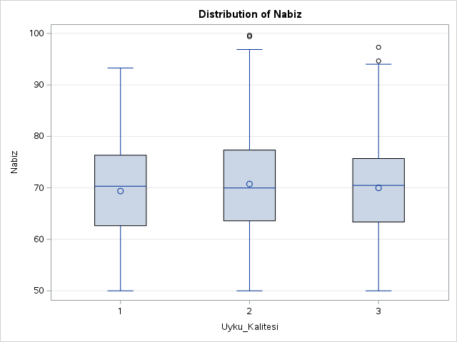

The GLM Procedure

Tukey's Studentized Range (HSD) Test for Nabiz

Note:This test controls the Type I experimentwise error rate.

| Alpha | 0.05 |
| --- | --- |
| Error Degrees of Freedom | 991 |
| Error Mean Square | 90.64172 |
| Critical Value of Studentized Range | 3.31949 |

| Comparisons significant at the 0.05 level are indicated by ***. Uyku_Kalitesi Comparison | Comparisons significant at the 0.05 level are indicated by ***. Difference Between Means | Comparisons significant at the 0.05 level are indicated by ***. Simultaneous 95% Confidence Limits | Comparisons significant at the 0.05 level are indicated by ***. Simultaneous 95% Confidence Limits | Comparisons significant at the 0.05 level are indicated by ***. |
| --- | --- | --- | --- | --- |
| 2 - 3 | 0.7617 | -0.8604 | 2.3837 |  |
| 2 - 1 | 1.3695 | -0.6189 | 3.3578 |  |
| 3 - 2 | -0.7617 | -2.3837 | 0.8604 |  |
| 3 - 1 | 0.6078 | -1.2453 | 2.4609 |  |
| 1 - 2 | -1.3695 | -3.3578 | 0.6189 |  |
| 1 - 3 | -0.6078 | -2.4609 | 1.2453 |  |

The GLM Procedure

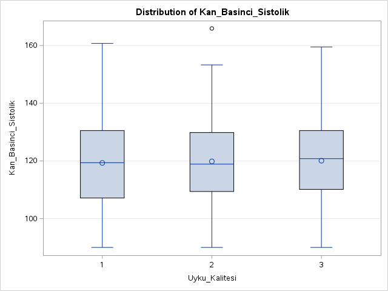

The GLM Procedure

Tukey's Studentized Range (HSD) Test for Kan_Basinci_Sistolik

Note:This test controls the Type I experimentwise error rate.

| Alpha | 0.05 |
| --- | --- |
| Error Degrees of Freedom | 991 |
| Error Mean Square | 214.0125 |
| Critical Value of Studentized Range | 3.31949 |

| Comparisons significant at the 0.05 level are indicated by ***. Uyku_Kalitesi Comparison | Comparisons significant at the 0.05 level are indicated by ***. Difference Between Means | Comparisons significant at the 0.05 level are indicated by ***. Simultaneous 95% Confidence Limits | Comparisons significant at the 0.05 level are indicated by ***. Simultaneous 95% Confidence Limits | Comparisons significant at the 0.05 level are indicated by ***. |
| --- | --- | --- | --- | --- |
| 3 - 2 | 0.2313 | -2.2612 | 2.7237 |  |
| 3 - 1 | 0.7723 | -2.0751 | 3.6197 |  |
| 2 - 3 | -0.2313 | -2.7237 | 2.2612 |  |
| 2 - 1 | 0.5410 | -2.5142 | 3.5962 |  |
| 1 - 3 | -0.7723 | -3.6197 | 2.0751 |  |
| 1 - 2 | -0.5410 | -3.5962 | 2.5142 |  |

The GLM Procedure

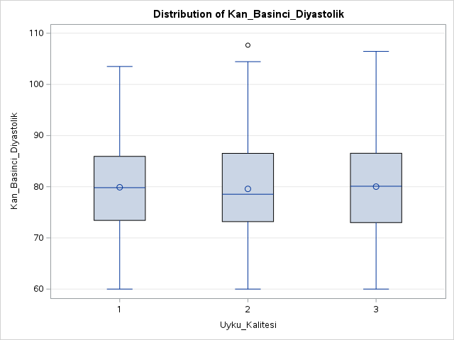

The GLM Procedure

Tukey's Studentized Range (HSD) Test for Kan_Basinci_Diyastolik

Note:This test controls the Type I experimentwise error rate.

| Alpha | 0.05 |
| --- | --- |
| Error Degrees of Freedom | 991 |
| Error Mean Square | 93.525 |
| Critical Value of Studentized Range | 3.31949 |

| Comparisons significant at the 0.05 level are indicated by ***. Uyku_Kalitesi Comparison | Comparisons significant at the 0.05 level are indicated by ***. Difference Between Means | Comparisons significant at the 0.05 level are indicated by ***. Simultaneous 95% Confidence Limits | Comparisons significant at the 0.05 level are indicated by ***. Simultaneous 95% Confidence Limits | Comparisons significant at the 0.05 level are indicated by ***. |
| --- | --- | --- | --- | --- |
| 3 - 1 | 0.1219 | -1.7604 | 2.0042 |  |
| 3 - 2 | 0.4396 | -1.2081 | 2.0872 |  |
| 1 - 3 | -0.1219 | -2.0042 | 1.7604 |  |
| 1 - 2 | 0.3177 | -1.7020 | 2.3374 |  |
| 2 - 3 | -0.4396 | -2.0872 | 1.2081 |  |
| 2 - 1 | -0.3177 | -2.3374 | 1.7020 |  |

The GLM Procedure

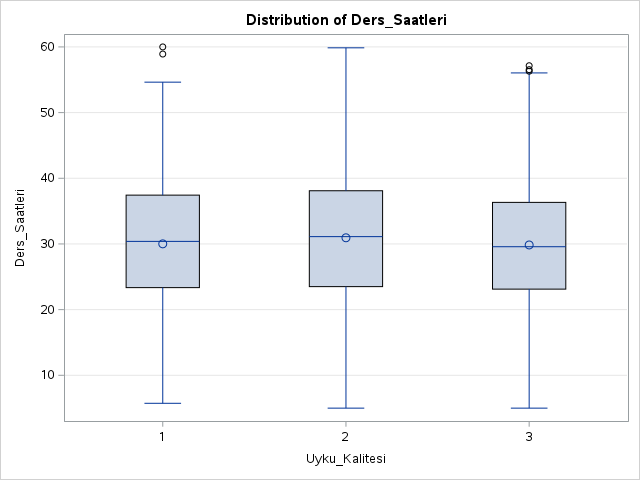

The GLM Procedure

Tukey's Studentized Range (HSD) Test for Ders_Saatleri

Note:This test controls the Type I experimentwise error rate.

| Alpha | 0.05 |
| --- | --- |
| Error Degrees of Freedom | 991 |
| Error Mean Square | 107.0121 |
| Critical Value of Studentized Range | 3.31949 |

| Comparisons significant at the 0.05 level are indicated by ***. Uyku_Kalitesi Comparison | Comparisons significant at the 0.05 level are indicated by ***. Difference Between Means | Comparisons significant at the 0.05 level are indicated by ***. Simultaneous 95% Confidence Limits | Comparisons significant at the 0.05 level are indicated by ***. Simultaneous 95% Confidence Limits | Comparisons significant at the 0.05 level are indicated by ***. |
| --- | --- | --- | --- | --- |
| 2 - 1 | 0.9231 | -1.2373 | 3.0835 |  |
| 2 - 3 | 1.0927 | -0.6698 | 2.8552 |  |
| 1 - 2 | -0.9231 | -3.0835 | 1.2373 |  |
| 1 - 3 | 0.1695 | -1.8439 | 2.1830 |  |
| 3 - 2 | -1.0927 | -2.8552 | 0.6698 |  |
| 3 - 1 | -0.1695 | -2.1830 | 1.8439 |  |

The GLM Procedure

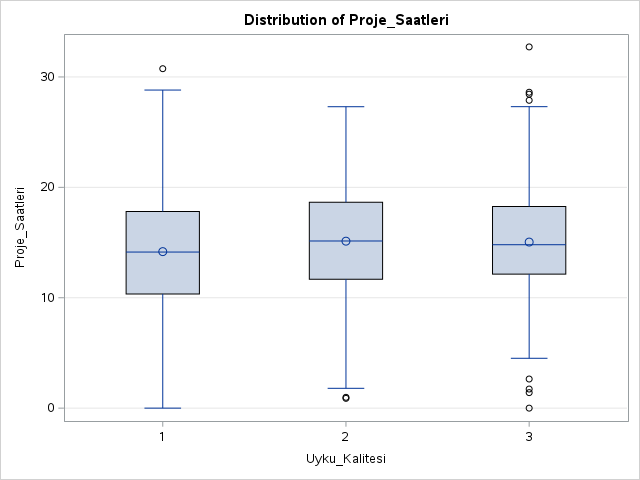

The GLM Procedure

Tukey's Studentized Range (HSD) Test for Proje_Saatleri

Note:This test controls the Type I experimentwise error rate.

| Alpha | 0.05 |
| --- | --- |
| Error Degrees of Freedom | 991 |
| Error Mean Square | 23.77564 |
| Critical Value of Studentized Range | 3.31949 |

| Comparisons significant at the 0.05 level are indicated by ***. Uyku_Kalitesi Comparison | Comparisons significant at the 0.05 level are indicated by ***. Difference Between Means | Comparisons significant at the 0.05 level are indicated by ***. Simultaneous 95% Confidence Limits | Comparisons significant at the 0.05 level are indicated by ***. Simultaneous 95% Confidence Limits | Comparisons significant at the 0.05 level are indicated by ***. |
| --- | --- | --- | --- | --- |
| 2 - 3 | 0.0808 | -0.7500 | 0.9116 |  |
| 2 - 1 | 0.9474 | -0.0709 | 1.9658 |  |
| 3 - 2 | -0.0808 | -0.9116 | 0.7500 |  |
| 3 - 1 | 0.8666 | -0.0824 | 1.8157 |  |
| 1 - 2 | -0.9474 | -1.9658 | 0.0709 |  |
| 1 - 3 | -0.8666 | -1.8157 | 0.0824 |  |

The GLM Procedure

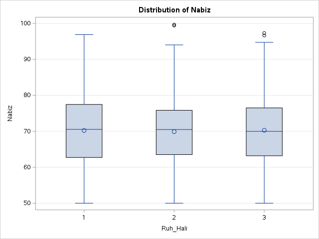

The GLM Procedure

Tukey's Studentized Range (HSD) Test for Nabiz

Note:This test controls the Type I experimentwise error rate.

| Alpha | 0.05 |
| --- | --- |
| Error Degrees of Freedom | 991 |
| Error Mean Square | 90.64172 |
| Critical Value of Studentized Range | 3.31949 |

| Comparisons significant at the 0.05 level are indicated by ***. Ruh_Hali Comparison | Comparisons significant at the 0.05 level are indicated by ***. Difference Between Means | Comparisons significant at the 0.05 level are indicated by ***. Simultaneous 95% Confidence Limits | Comparisons significant at the 0.05 level are indicated by ***. Simultaneous 95% Confidence Limits | Comparisons significant at the 0.05 level are indicated by ***. |
| --- | --- | --- | --- | --- |
| 3 - 1 | 0.0610 | -1.9231 | 2.0450 |  |
| 3 - 2 | 0.3801 | -1.1867 | 1.9470 |  |
| 1 - 3 | -0.0610 | -2.0450 | 1.9231 |  |
| 1 - 2 | 0.3191 | -1.6527 | 2.2910 |  |
| 2 - 3 | -0.3801 | -1.9470 | 1.1867 |  |
| 2 - 1 | -0.3191 | -2.2910 | 1.6527 |  |

The GLM Procedure

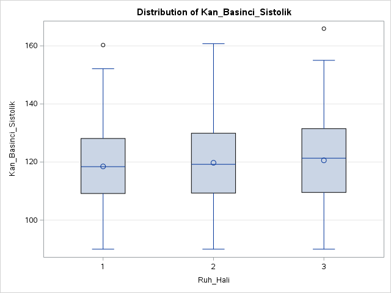

The GLM Procedure

Tukey's Studentized Range (HSD) Test for Kan_Basinci_Sistolik

Note:This test controls the Type I experimentwise error rate.

| Alpha | 0.05 |
| --- | --- |
| Error Degrees of Freedom | 991 |
| Error Mean Square | 214.0125 |
| Critical Value of Studentized Range | 3.31949 |

| Comparisons significant at the 0.05 level are indicated by ***. Ruh_Hali Comparison | Comparisons significant at the 0.05 level are indicated by ***. Difference Between Means | Comparisons significant at the 0.05 level are indicated by ***. Simultaneous 95% Confidence Limits | Comparisons significant at the 0.05 level are indicated by ***. Simultaneous 95% Confidence Limits | Comparisons significant at the 0.05 level are indicated by ***. |
| --- | --- | --- | --- | --- |
| 3 - 2 | 0.825 | -1.583 | 3.232 |  |
| 3 - 1 | 2.083 | -0.966 | 5.132 |  |
| 2 - 3 | -0.825 | -3.232 | 1.583 |  |
| 2 - 1 | 1.258 | -1.772 | 4.288 |  |
| 1 - 3 | -2.083 | -5.132 | 0.966 |  |
| 1 - 2 | -1.258 | -4.288 | 1.772 |  |

The GLM Procedure

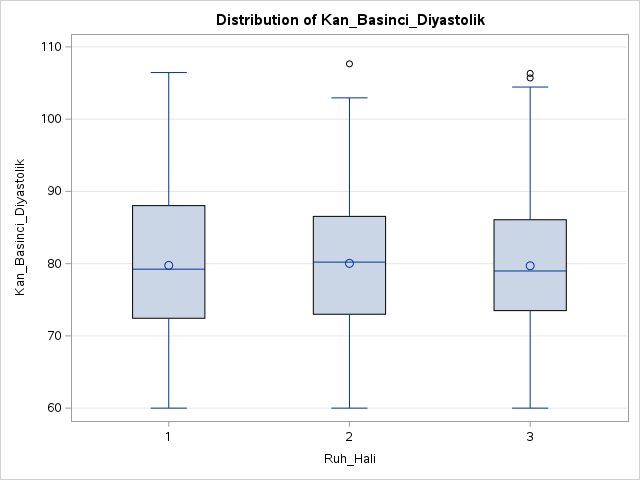

The GLM Procedure

Tukey's Studentized Range (HSD) Test for Kan_Basinci_Diyastolik

Note:This test controls the Type I experimentwise error rate.

| Alpha | 0.05 |
| --- | --- |
| Error Degrees of Freedom | 991 |
| Error Mean Square | 93.525 |
| Critical Value of Studentized Range | 3.31949 |

| Comparisons significant at the 0.05 level are indicated by ***. Ruh_Hali Comparison | Comparisons significant at the 0.05 level are indicated by ***. Difference Between Means | Comparisons significant at the 0.05 level are indicated by ***. Simultaneous 95% Confidence Limits | Comparisons significant at the 0.05 level are indicated by ***. Simultaneous 95% Confidence Limits | Comparisons significant at the 0.05 level are indicated by ***. |
| --- | --- | --- | --- | --- |
| 2 - 1 | 0.2805 | -1.7225 | 2.2835 |  |
| 2 - 3 | 0.3326 | -1.2590 | 1.9242 |  |
| 1 - 2 | -0.2805 | -2.2835 | 1.7225 |  |
| 1 - 3 | 0.0521 | -1.9633 | 2.0675 |  |
| 3 - 2 | -0.3326 | -1.9242 | 1.2590 |  |
| 3 - 1 | -0.0521 | -2.0675 | 1.9633 |  |

The GLM Procedure

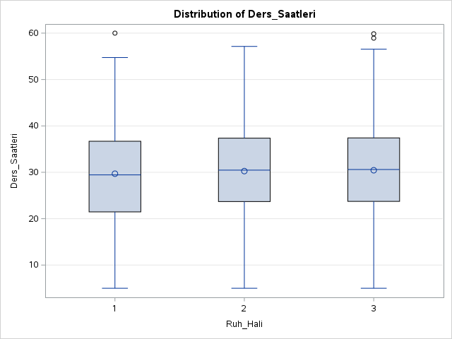

The GLM Procedure

Tukey's Studentized Range (HSD) Test for Ders_Saatleri

Note:This test controls the Type I experimentwise error rate.

| Alpha | 0.05 |
| --- | --- |
| Error Degrees of Freedom | 991 |
| Error Mean Square | 107.0121 |
| Critical Value of Studentized Range | 3.31949 |

| Comparisons significant at the 0.05 level are indicated by ***. Ruh_Hali Comparison | Comparisons significant at the 0.05 level are indicated by ***. Difference Between Means | Comparisons significant at the 0.05 level are indicated by ***. Simultaneous 95% Confidence Limits | Comparisons significant at the 0.05 level are indicated by ***. Simultaneous 95% Confidence Limits | Comparisons significant at the 0.05 level are indicated by ***. |
| --- | --- | --- | --- | --- |
| 3 - 2 | 0.1803 | -1.5222 | 1.8827 |  |
| 3 - 1 | 0.7442 | -1.4116 | 2.9000 |  |
| 2 - 3 | -0.1803 | -1.8827 | 1.5222 |  |
| 2 - 1 | 0.5639 | -1.5786 | 2.7065 |  |
| 1 - 3 | -0.7442 | -2.9000 | 1.4116 |  |
| 1 - 2 | -0.5639 | -2.7065 | 1.5786 |  |

The GLM Procedure

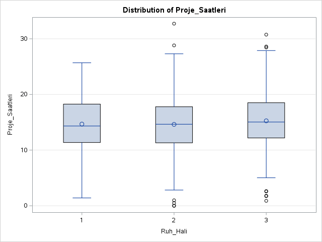

The GLM Procedure

Tukey's Studentized Range (HSD) Test for Proje_Saatleri

Note:This test controls the Type I experimentwise error rate.

| Alpha | 0.05 |
| --- | --- |
| Error Degrees of Freedom | 991 |
| Error Mean Square | 23.77564 |
| Critical Value of Studentized Range | 3.31949 |

| Comparisons significant at the 0.05 level are indicated by ***. Ruh_Hali Comparison | Comparisons significant at the 0.05 level are indicated by ***. Difference Between Means | Comparisons significant at the 0.05 level are indicated by ***. Simultaneous 95% Confidence Limits | Comparisons significant at the 0.05 level are indicated by ***. Simultaneous 95% Confidence Limits | Comparisons significant at the 0.05 level are indicated by ***. |
| --- | --- | --- | --- | --- |
| 3 - 1 | 0.5819 | -0.4342 | 1.5981 |  |
| 3 - 2 | 0.6400 | -0.1625 | 1.4424 |  |
| 1 - 3 | -0.5819 | -1.5981 | 0.4342 |  |
| 1 - 2 | 0.0580 | -0.9519 | 1.0679 |  |
| 2 - 3 | -0.6400 | -1.4424 | 0.1625 |  |
| 2 - 1 | -0.0580 | -1.0679 | 0.9519 |  |

The GLM Procedure

Least Squares Means

Adjustment for Multiple Comparisons: Tukey-Kramer

| Uyku_Kalitesi | Ruh_Hali | Nabiz LSMEAN | LSMEAN Number |
| --- | --- | --- | --- |
| 1 | 1 | 70.2990763 | 1 |
| 1 | 2 | 70.0036439 | 2 |
| 1 | 3 | 68.3766699 | 3 |
| 2 | 1 | 70.1489651 | 4 |
| 2 | 2 | 69.2855387 | 5 |
| 2 | 3 | 72.5854606 | 6 |
| 3 | 1 | 70.2121928 | 7 |
| 3 | 2 | 70.2633716 | 8 |
| 3 | 3 | 69.5891099 | 9 |

| Least Squares Means for effect Uyku_Kalite*Ruh_Hali Pr > \|t\| for H0: LSMean(i)=LSMean(j) Dependent Variable: Nabiz i/j | Least Squares Means for effect Uyku_Kalite*Ruh_Hali Pr > \|t\| for H0: LSMean(i)=LSMean(j) Dependent Variable: Nabiz 1 | Least Squares Means for effect Uyku_Kalite*Ruh_Hali Pr > \|t\| for H0: LSMean(i)=LSMean(j) Dependent Variable: Nabiz 2 | Least Squares Means for effect Uyku_Kalite*Ruh_Hali Pr > \|t\| for H0: LSMean(i)=LSMean(j) Dependent Variable: Nabiz 3 | Least Squares Means for effect Uyku_Kalite*Ruh_Hali Pr > \|t\| for H0: LSMean(i)=LSMean(j) Dependent Variable: Nabiz 4 | Least Squares Means for effect Uyku_Kalite*Ruh_Hali Pr > \|t\| for H0: LSMean(i)=LSMean(j) Dependent Variable: Nabiz 5 | Least Squares Means for effect Uyku_Kalite*Ruh_Hali Pr > \|t\| for H0: LSMean(i)=LSMean(j) Dependent Variable: Nabiz 6 | Least Squares Means for effect Uyku_Kalite*Ruh_Hali Pr > \|t\| for H0: LSMean(i)=LSMean(j) Dependent Variable: Nabiz 7 | Least Squares Means for effect Uyku_Kalite*Ruh_Hali Pr > \|t\| for H0: LSMean(i)=LSMean(j) Dependent Variable: Nabiz 8 | Least Squares Means for effect Uyku_Kalite*Ruh_Hali Pr > \|t\| for H0: LSMean(i)=LSMean(j) Dependent Variable: Nabiz 9 |
| --- | --- | --- | --- | --- | --- | --- | --- | --- | --- |
| 1 |  | 1.0000 | 0.9841 | 1.0000 | 0.9997 | 0.9396 | 1.0000 | 1.0000 | 1.0000 |
| 2 | 1.0000 |  | 0.9701 | 1.0000 | 0.9998 | 0.5821 | 1.0000 | 1.0000 | 1.0000 |
| 3 | 0.9841 | 0.9701 |  | 0.9761 | 0.9989 | 0.0414 | 0.9326 | 0.8391 | 0.9876 |
| 4 | 1.0000 | 1.0000 | 0.9761 |  | 0.9997 | 0.8085 | 1.0000 | 1.0000 | 1.0000 |
| 5 | 0.9997 | 0.9998 | 0.9989 | 0.9997 |  | 0.1171 | 0.9985 | 0.9921 | 1.0000 |
| 6 | 0.9396 | 0.5821 | 0.0414 | 0.8085 | 0.1171 |  | 0.6628 | 0.4536 | 0.1394 |
| 7 | 1.0000 | 1.0000 | 0.9326 | 1.0000 | 0.9985 | 0.6628 |  | 1.0000 | 0.9999 |
| 8 | 1.0000 | 1.0000 | 0.8391 | 1.0000 | 0.9921 | 0.4536 | 1.0000 |  | 0.9989 |
| 9 | 1.0000 | 1.0000 | 0.9876 | 1.0000 | 1.0000 | 0.1394 | 0.9999 | 0.9989 |  |

[figure not shown]

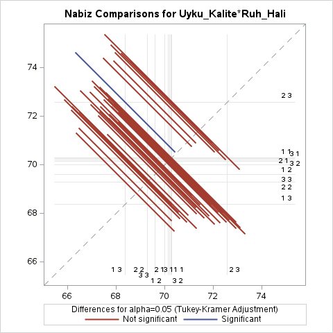

| Uyku_Kalitesi | Ruh_Hali | Kan_Basinci_Sistolik LSMEAN | LSMEAN Number |
| --- | --- | --- | --- |
| 1 | 1 | 119.541035 | 1 |
| 1 | 2 | 119.324282 | 2 |
| 1 | 3 | 119.172530 | 3 |
| 2 | 1 | 117.829875 | 4 |
| 2 | 2 | 120.252870 | 5 |
| 2 | 3 | 120.290018 | 6 |
| 3 | 1 | 118.465089 | 7 |
| 3 | 2 | 119.569279 | 8 |
| 3 | 3 | 121.402892 | 9 |

| Least Squares Means for effect Uyku_Kalite*Ruh_Hali Pr > \|t\| for H0: LSMean(i)=LSMean(j) Dependent Variable: Kan_Basinci_Sistolik i/j | Least Squares Means for effect Uyku_Kalite*Ruh_Hali Pr > \|t\| for H0: LSMean(i)=LSMean(j) Dependent Variable: Kan_Basinci_Sistolik 1 | Least Squares Means for effect Uyku_Kalite*Ruh_Hali Pr > \|t\| for H0: LSMean(i)=LSMean(j) Dependent Variable: Kan_Basinci_Sistolik 2 | Least Squares Means for effect Uyku_Kalite*Ruh_Hali Pr > \|t\| for H0: LSMean(i)=LSMean(j) Dependent Variable: Kan_Basinci_Sistolik 3 | Least Squares Means for effect Uyku_Kalite*Ruh_Hali Pr > \|t\| for H0: LSMean(i)=LSMean(j) Dependent Variable: Kan_Basinci_Sistolik 4 | Least Squares Means for effect Uyku_Kalite*Ruh_Hali Pr > \|t\| for H0: LSMean(i)=LSMean(j) Dependent Variable: Kan_Basinci_Sistolik 5 | Least Squares Means for effect Uyku_Kalite*Ruh_Hali Pr > \|t\| for H0: LSMean(i)=LSMean(j) Dependent Variable: Kan_Basinci_Sistolik 6 | Least Squares Means for effect Uyku_Kalite*Ruh_Hali Pr > \|t\| for H0: LSMean(i)=LSMean(j) Dependent Variable: Kan_Basinci_Sistolik 7 | Least Squares Means for effect Uyku_Kalite*Ruh_Hali Pr > \|t\| for H0: LSMean(i)=LSMean(j) Dependent Variable: Kan_Basinci_Sistolik 8 | Least Squares Means for effect Uyku_Kalite*Ruh_Hali Pr > \|t\| for H0: LSMean(i)=LSMean(j) Dependent Variable: Kan_Basinci_Sistolik 9 |
| --- | --- | --- | --- | --- | --- | --- | --- | --- | --- |
| 1 |  | 1.0000 | 1.0000 | 0.9998 | 1.0000 | 1.0000 | 1.0000 | 1.0000 | 0.9988 |
| 2 | 1.0000 |  | 1.0000 | 0.9996 | 0.9999 | 0.9999 | 1.0000 | 1.0000 | 0.9751 |
| 3 | 1.0000 | 1.0000 |  | 0.9998 | 0.9998 | 0.9998 | 1.0000 | 1.0000 | 0.9619 |
| 4 | 0.9998 | 0.9996 | 0.9998 |  | 0.9817 | 0.9811 | 1.0000 | 0.9973 | 0.8037 |
| 5 | 1.0000 | 0.9999 | 0.9998 | 0.9817 |  | 1.0000 | 0.9924 | 1.0000 | 0.9988 |
| 6 | 1.0000 | 0.9999 | 0.9998 | 0.9811 | 1.0000 |  | 0.9921 | 1.0000 | 0.9992 |
| 7 | 1.0000 | 1.0000 | 1.0000 | 1.0000 | 0.9924 | 0.9921 |  | 0.9996 | 0.8121 |
| 8 | 1.0000 | 1.0000 | 1.0000 | 0.9973 | 1.0000 | 1.0000 | 0.9996 |  | 0.9522 |
| 9 | 0.9988 | 0.9751 | 0.9619 | 0.8037 | 0.9988 | 0.9992 | 0.8121 | 0.9522 |  |

[figure not shown]

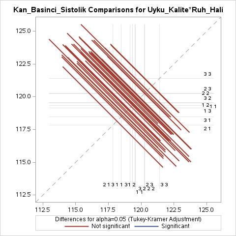

| Uyku_Kalitesi | Ruh_Hali | Kan_Basinci_Diyastolik LSMEAN | LSMEAN Number |
| --- | --- | --- | --- |
| 1 | 1 | 78.4631245 | 1 |
| 1 | 2 | 80.0966415 | 2 |
| 1 | 3 | 80.2926759 | 3 |
| 2 | 1 | 79.5508771 | 4 |
| 2 | 2 | 79.9249725 | 5 |
| 2 | 3 | 79.2236472 | 6 |
| 3 | 1 | 80.3795717 | 7 |
| 3 | 2 | 80.0941391 | 8 |
| 3 | 3 | 79.7605602 | 9 |

| Least Squares Means for effect Uyku_Kalite*Ruh_Hali Pr > \|t\| for H0: LSMean(i)=LSMean(j) Dependent Variable: Kan_Basinci_Diyastolik i/j | Least Squares Means for effect Uyku_Kalite*Ruh_Hali Pr > \|t\| for H0: LSMean(i)=LSMean(j) Dependent Variable: Kan_Basinci_Diyastolik 1 | Least Squares Means for effect Uyku_Kalite*Ruh_Hali Pr > \|t\| for H0: LSMean(i)=LSMean(j) Dependent Variable: Kan_Basinci_Diyastolik 2 | Least Squares Means for effect Uyku_Kalite*Ruh_Hali Pr > \|t\| for H0: LSMean(i)=LSMean(j) Dependent Variable: Kan_Basinci_Diyastolik 3 | Least Squares Means for effect Uyku_Kalite*Ruh_Hali Pr > \|t\| for H0: LSMean(i)=LSMean(j) Dependent Variable: Kan_Basinci_Diyastolik 4 | Least Squares Means for effect Uyku_Kalite*Ruh_Hali Pr > \|t\| for H0: LSMean(i)=LSMean(j) Dependent Variable: Kan_Basinci_Diyastolik 5 | Least Squares Means for effect Uyku_Kalite*Ruh_Hali Pr > \|t\| for H0: LSMean(i)=LSMean(j) Dependent Variable: Kan_Basinci_Diyastolik 6 | Least Squares Means for effect Uyku_Kalite*Ruh_Hali Pr > \|t\| for H0: LSMean(i)=LSMean(j) Dependent Variable: Kan_Basinci_Diyastolik 7 | Least Squares Means for effect Uyku_Kalite*Ruh_Hali Pr > \|t\| for H0: LSMean(i)=LSMean(j) Dependent Variable: Kan_Basinci_Diyastolik 8 | Least Squares Means for effect Uyku_Kalite*Ruh_Hali Pr > \|t\| for H0: LSMean(i)=LSMean(j) Dependent Variable: Kan_Basinci_Diyastolik 9 |
| --- | --- | --- | --- | --- | --- | --- | --- | --- | --- |
| 1 |  | 0.9951 | 0.9896 | 0.9999 | 0.9967 | 1.0000 | 0.9849 | 0.9913 | 0.9983 |
| 2 | 0.9951 |  | 1.0000 | 1.0000 | 1.0000 | 0.9993 | 1.0000 | 1.0000 | 1.0000 |
| 3 | 0.9896 | 1.0000 |  | 1.0000 | 1.0000 | 0.9971 | 1.0000 | 1.0000 | 1.0000 |
| 4 | 0.9999 | 1.0000 | 1.0000 |  | 1.0000 | 1.0000 | 0.9999 | 1.0000 | 1.0000 |
| 5 | 0.9967 | 1.0000 | 1.0000 | 1.0000 |  | 0.9997 | 1.0000 | 1.0000 | 1.0000 |
| 6 | 1.0000 | 0.9993 | 0.9971 | 1.0000 | 0.9997 |  | 0.9941 | 0.9972 | 0.9999 |
| 7 | 0.9849 | 1.0000 | 1.0000 | 0.9999 | 1.0000 | 0.9941 |  | 1.0000 | 0.9999 |
| 8 | 0.9913 | 1.0000 | 1.0000 | 1.0000 | 1.0000 | 0.9972 | 1.0000 |  | 1.0000 |
| 9 | 0.9983 | 1.0000 | 1.0000 | 1.0000 | 1.0000 | 0.9999 | 0.9999 | 1.0000 |  |

[figure not shown]

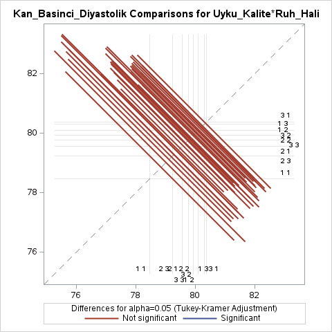

| Uyku_Kalitesi | Ruh_Hali | Ders_Saatleri LSMEAN | LSMEAN Number |
| --- | --- | --- | --- |
| 1 | 1 | 31.7639778 | 1 |
| 1 | 2 | 28.6924513 | 2 |
| 1 | 3 | 30.6128798 | 3 |
| 2 | 1 | 29.4774910 | 4 |
| 2 | 2 | 31.5640631 | 5 |
| 2 | 3 | 30.9156430 | 6 |
| 3 | 1 | 29.0343517 | 7 |
| 3 | 2 | 30.0544405 | 8 |
| 3 | 3 | 30.0375002 | 9 |

| Least Squares Means for effect Uyku_Kalite*Ruh_Hali Pr > \|t\| for H0: LSMean(i)=LSMean(j) Dependent Variable: Ders_Saatleri i/j | Least Squares Means for effect Uyku_Kalite*Ruh_Hali Pr > \|t\| for H0: LSMean(i)=LSMean(j) Dependent Variable: Ders_Saatleri 1 | Least Squares Means for effect Uyku_Kalite*Ruh_Hali Pr > \|t\| for H0: LSMean(i)=LSMean(j) Dependent Variable: Ders_Saatleri 2 | Least Squares Means for effect Uyku_Kalite*Ruh_Hali Pr > \|t\| for H0: LSMean(i)=LSMean(j) Dependent Variable: Ders_Saatleri 3 | Least Squares Means for effect Uyku_Kalite*Ruh_Hali Pr > \|t\| for H0: LSMean(i)=LSMean(j) Dependent Variable: Ders_Saatleri 4 | Least Squares Means for effect Uyku_Kalite*Ruh_Hali Pr > \|t\| for H0: LSMean(i)=LSMean(j) Dependent Variable: Ders_Saatleri 5 | Least Squares Means for effect Uyku_Kalite*Ruh_Hali Pr > \|t\| for H0: LSMean(i)=LSMean(j) Dependent Variable: Ders_Saatleri 6 | Least Squares Means for effect Uyku_Kalite*Ruh_Hali Pr > \|t\| for H0: LSMean(i)=LSMean(j) Dependent Variable: Ders_Saatleri 7 | Least Squares Means for effect Uyku_Kalite*Ruh_Hali Pr > \|t\| for H0: LSMean(i)=LSMean(j) Dependent Variable: Ders_Saatleri 8 | Least Squares Means for effect Uyku_Kalite*Ruh_Hali Pr > \|t\| for H0: LSMean(i)=LSMean(j) Dependent Variable: Ders_Saatleri 9 |
| --- | --- | --- | --- | --- | --- | --- | --- | --- | --- |
| 1 |  | 0.8565 | 0.9998 | 0.9825 | 1.0000 | 1.0000 | 0.9170 | 0.9924 | 0.9921 |
| 2 | 0.8565 |  | 0.9511 | 1.0000 | 0.5303 | 0.8355 | 1.0000 | 0.9840 | 0.9858 |
| 3 | 0.9998 | 0.9511 |  | 0.9994 | 0.9991 | 1.0000 | 0.9834 | 1.0000 | 1.0000 |
| 4 | 0.9825 | 1.0000 | 0.9994 |  | 0.9401 | 0.9946 | 1.0000 | 1.0000 | 1.0000 |
| 5 | 1.0000 | 0.5303 | 0.9991 | 0.9401 |  | 0.9999 | 0.6686 | 0.9312 | 0.9299 |
| 6 | 1.0000 | 0.8355 | 1.0000 | 0.9946 | 0.9999 |  | 0.9209 | 0.9984 | 0.9983 |
| 7 | 0.9170 | 1.0000 | 0.9834 | 1.0000 | 0.6686 | 0.9209 |  | 0.9973 | 0.9977 |
| 8 | 0.9924 | 0.9840 | 1.0000 | 1.0000 | 0.9312 | 0.9984 | 0.9973 |  | 1.0000 |
| 9 | 0.9921 | 0.9858 | 1.0000 | 1.0000 | 0.9299 | 0.9983 | 0.9977 | 1.0000 |  |

[figure not shown]

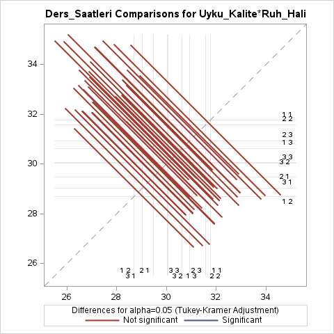

| Uyku_Kalitesi | Ruh_Hali | Proje_Saatleri LSMEAN | LSMEAN Number |
| --- | --- | --- | --- |
| 1 | 1 | 13.3676912 | 1 |
| 1 | 2 | 14.1392197 | 2 |
| 1 | 3 | 14.5499642 | 3 |
| 2 | 1 | 14.3713527 | 4 |
| 2 | 2 | 14.7966044 | 5 |
| 2 | 3 | 15.8106596 | 6 |
| 3 | 1 | 15.3649748 | 7 |
| 3 | 2 | 14.7158405 | 8 |
| 3 | 3 | 15.2216516 | 9 |

| Least Squares Means for effect Uyku_Kalite*Ruh_Hali Pr > \|t\| for H0: LSMean(i)=LSMean(j) Dependent Variable: Proje_Saatleri i/j | Least Squares Means for effect Uyku_Kalite*Ruh_Hali Pr > \|t\| for H0: LSMean(i)=LSMean(j) Dependent Variable: Proje_Saatleri 1 | Least Squares Means for effect Uyku_Kalite*Ruh_Hali Pr > \|t\| for H0: LSMean(i)=LSMean(j) Dependent Variable: Proje_Saatleri 2 | Least Squares Means for effect Uyku_Kalite*Ruh_Hali Pr > \|t\| for H0: LSMean(i)=LSMean(j) Dependent Variable: Proje_Saatleri 3 | Least Squares Means for effect Uyku_Kalite*Ruh_Hali Pr > \|t\| for H0: LSMean(i)=LSMean(j) Dependent Variable: Proje_Saatleri 4 | Least Squares Means for effect Uyku_Kalite*Ruh_Hali Pr > \|t\| for H0: LSMean(i)=LSMean(j) Dependent Variable: Proje_Saatleri 5 | Least Squares Means for effect Uyku_Kalite*Ruh_Hali Pr > \|t\| for H0: LSMean(i)=LSMean(j) Dependent Variable: Proje_Saatleri 6 | Least Squares Means for effect Uyku_Kalite*Ruh_Hali Pr > \|t\| for H0: LSMean(i)=LSMean(j) Dependent Variable: Proje_Saatleri 7 | Least Squares Means for effect Uyku_Kalite*Ruh_Hali Pr > \|t\| for H0: LSMean(i)=LSMean(j) Dependent Variable: Proje_Saatleri 8 | Least Squares Means for effect Uyku_Kalite*Ruh_Hali Pr > \|t\| for H0: LSMean(i)=LSMean(j) Dependent Variable: Proje_Saatleri 9 |
| --- | --- | --- | --- | --- | --- | --- | --- | --- | --- |
| 1 |  | 0.9969 | 0.9513 | 0.9889 | 0.8250 | 0.1671 | 0.4808 | 0.8448 | 0.4820 |
| 2 | 0.9969 |  | 0.9998 | 1.0000 | 0.9876 | 0.2535 | 0.7529 | 0.9921 | 0.7410 |
| 3 | 0.9513 | 0.9998 |  | 1.0000 | 1.0000 | 0.6452 | 0.9707 | 1.0000 | 0.9795 |
| 4 | 0.9889 | 1.0000 | 1.0000 |  | 0.9998 | 0.6567 | 0.9550 | 0.9999 | 0.9673 |
| 5 | 0.8250 | 0.9876 | 1.0000 | 0.9998 |  | 0.7595 | 0.9945 | 1.0000 | 0.9976 |
| 6 | 0.1671 | 0.2535 | 0.6452 | 0.6567 | 0.7595 |  | 0.9991 | 0.5716 | 0.9811 |
| 7 | 0.4808 | 0.7529 | 0.9707 | 0.9550 | 0.9945 | 0.9991 |  | 0.9798 | 1.0000 |
| 8 | 0.8448 | 0.9921 | 1.0000 | 0.9999 | 1.0000 | 0.5716 | 0.9798 |  | 0.9850 |
| 9 | 0.4820 | 0.7410 | 0.9795 | 0.9673 | 0.9976 | 0.9811 | 1.0000 | 0.9850 |  |

[figure not shown]

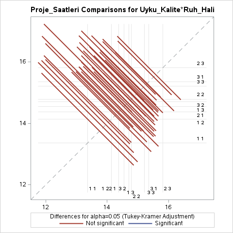

The GLM Procedure

| Class Level Information Class | Class Level Information Levels | Class Level Information Values |
| --- | --- | --- |
| Uyku_Kalitesi | 3 | 1 2 3 |
| Ruh_Hali | 3 | 1 2 3 |

| Number of Observations Read | 1000 |
| --- | --- |
| Number of Observations Used | 1000 |

The GLM Procedure

Dependent Variable: Nabiz Nabiz

| Source | DF | Sum of Squares | Mean Square | F Value | Pr > F |
| --- | --- | --- | --- | --- | --- |
| Model | 8 | 1183.54437 | 147.94305 | 1.63 | 0.1115 |
| Error | 991 | 89825.94551 | 90.64172 |  |  |
| Corrected Total | 999 | 91009.48989 |  |  |  |

| R-Square | Coeff Var | Root MSE | Nabiz Mean |
| --- | --- | --- | --- |
| 0.013005 | 13.58109 | 9.520595 | 70.10186 |

| Source | DF | Type III SS | Mean Square | F Value | Pr > F |
| --- | --- | --- | --- | --- | --- |
| Uyku_Kalitesi | 2 | 142.6546245 | 71.3273123 | 0.79 | 0.4555 |
| Ruh_Hali | 2 | 25.9355787 | 12.9677893 | 0.14 | 0.8667 |
| Uyku_Kalite*Ruh_Hali | 4 | 900.9032986 | 225.2258247 | 2.48 | 0.0422 |

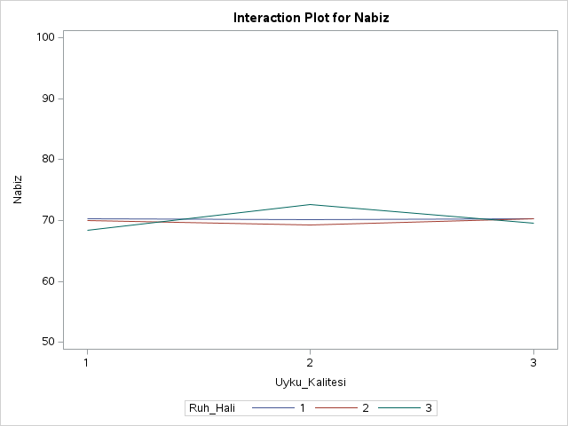

The GLM Procedure

Dependent Variable: Kan_Basinci_Sistolik Kan_Basinci_Sistolik

| Source | DF | Sum of Squares | Mean Square | F Value | Pr > F |
| --- | --- | --- | --- | --- | --- |
| Model | 8 | 986.0681 | 123.2585 | 0.58 | 0.7983 |
| Error | 991 | 212086.4362 | 214.0125 |  |  |
| Corrected Total | 999 | 213072.5044 |  |  |  |

| R-Square | Coeff Var | Root MSE | Kan_Basinci_Sistolik Mean |
| --- | --- | --- | --- |
| 0.004628 | 12.20772 | 14.62917 | 119.8354 |

| Source | DF | Type III SS | Mean Square | F Value | Pr > F |
| --- | --- | --- | --- | --- | --- |
| Uyku_Kalitesi | 2 | 36.0500328 | 18.0250164 | 0.08 | 0.9192 |
| Ruh_Hali | 2 | 312.7643825 | 156.3821912 | 0.73 | 0.4818 |
| Uyku_Kalite*Ruh_Hali | 4 | 330.3441984 | 82.5860496 | 0.39 | 0.8188 |

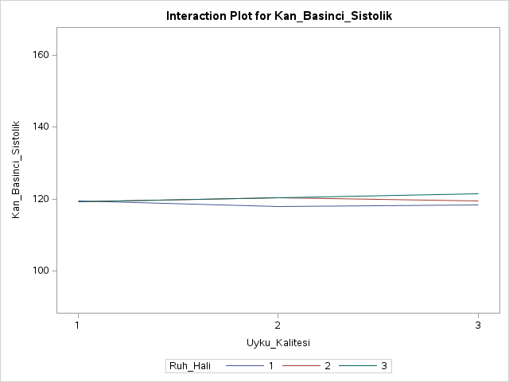

The GLM Procedure

Dependent Variable: Kan_Basinci_Diyastolik Kan_Basinci_Diyastolik

| Source | DF | Sum of Squares | Mean Square | F Value | Pr > F |
| --- | --- | --- | --- | --- | --- |
| Model | 8 | 186.11654 | 23.26457 | 0.25 | 0.9812 |
| Error | 991 | 92683.27505 | 93.52500 |  |  |
| Corrected Total | 999 | 92869.39159 |  |  |  |

| R-Square | Coeff Var | Root MSE | Kan_Basinci_Diyastolik Mean |
| --- | --- | --- | --- |
| 0.002004 | 12.11053 | 9.670832 | 79.85476 |

| Source | DF | Type III SS | Mean Square | F Value | Pr > F |
| --- | --- | --- | --- | --- | --- |
| Uyku_Kalitesi | 2 | 52.9463685 | 26.4731843 | 0.28 | 0.7535 |
| Ruh_Hali | 2 | 39.4087717 | 19.7043858 | 0.21 | 0.8101 |
| Uyku_Kalite*Ruh_Hali | 4 | 123.5135331 | 30.8783833 | 0.33 | 0.8578 |

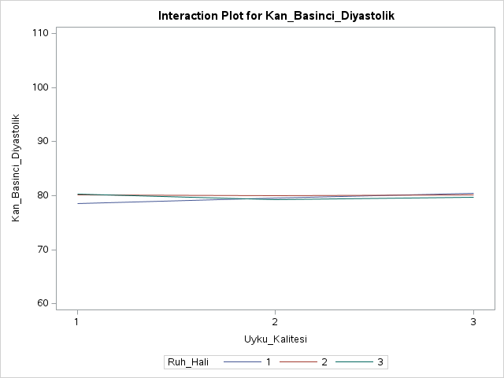

The GLM Procedure

Dependent Variable: Ders_Saatleri Ders_Saatleri

| Source | DF | Sum of Squares | Mean Square | F Value | Pr > F |
| --- | --- | --- | --- | --- | --- |
| Model | 8 | 781.5575 | 97.6947 | 0.91 | 0.5048 |
| Error | 991 | 106049.0336 | 107.0121 |  |  |
| Corrected Total | 999 | 106830.5911 |  |  |  |

| R-Square | Coeff Var | Root MSE | Ders_Saatleri Mean |
| --- | --- | --- | --- |
| 0.007316 | 34.22323 | 10.34467 | 30.22704 |

| Source | DF | Type III SS | Mean Square | F Value | Pr > F |
| --- | --- | --- | --- | --- | --- |
| Uyku_Kalitesi | 2 | 158.3995042 | 79.1997521 | 0.74 | 0.4773 |
| Ruh_Hali | 2 | 38.4518266 | 19.2259133 | 0.18 | 0.8356 |
| Uyku_Kalite*Ruh_Hali | 4 | 475.9990675 | 118.9997669 | 1.11 | 0.3494 |

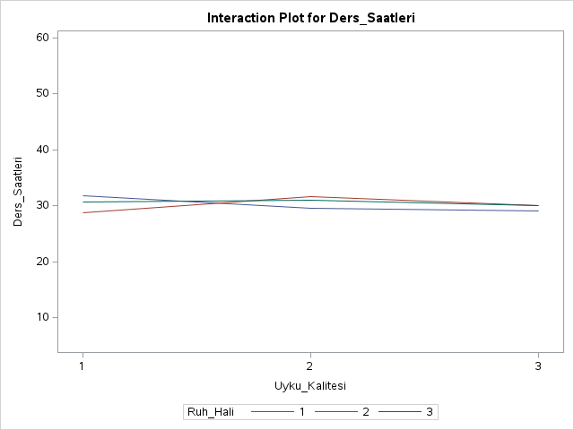

The GLM Procedure

Dependent Variable: Proje_Saatleri Proje_Saatleri

| Source | DF | Sum of Squares | Mean Square | F Value | Pr > F |
| --- | --- | --- | --- | --- | --- |
| Model | 8 | 313.07887 | 39.13486 | 1.65 | 0.1078 |
| Error | 991 | 23561.66239 | 23.77564 |  |  |
| Corrected Total | 999 | 23874.74126 |  |  |  |

| R-Square | Coeff Var | Root MSE | Proje_Saatleri Mean |
| --- | --- | --- | --- |
| 0.013113 | 32.75278 | 4.876027 | 14.88737 |

| Source | DF | Type III SS | Mean Square | F Value | Pr > F |
| --- | --- | --- | --- | --- | --- |
| Uyku_Kalitesi | 2 | 154.6781936 | 77.3390968 | 3.25 | 0.0391 |
| Ruh_Hali | 2 | 109.0286010 | 54.5143005 | 2.29 | 0.1015 |
| Uyku_Kalite*Ruh_Hali | 4 | 81.1310174 | 20.2827543 | 0.85 | 0.4917 |

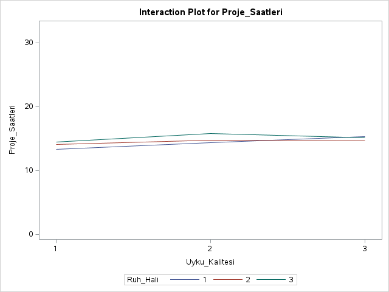

The GLM Procedure

Multivariate Analysis of Variance

| Characteristic Roots and Vectors of: E Inverse * H, where H = Type III SSCP Matrix for Uyku_Kalitesi E = Error SSCP Matrix Characteristic Root | Characteristic Roots and Vectors of: E Inverse * H, where H = Type III SSCP Matrix for Uyku_Kalitesi E = Error SSCP Matrix Percent | Characteristic Roots and Vectors of: E Inverse * H, where H = Type III SSCP Matrix for Uyku_Kalitesi E = Error SSCP Matrix Characteristic Vector V'EV=1 Nabiz | Characteristic Roots and Vectors of: E Inverse * H, where H = Type III SSCP Matrix for Uyku_Kalitesi E = Error SSCP Matrix Characteristic Vector V'EV=1 Kan_Basinci_Sistolik | Characteristic Roots and Vectors of: E Inverse * H, where H = Type III SSCP Matrix for Uyku_Kalitesi E = Error SSCP Matrix Characteristic Vector V'EV=1 Kan_Basinci_Diyastolik | Characteristic Roots and Vectors of: E Inverse * H, where H = Type III SSCP Matrix for Uyku_Kalitesi E = Error SSCP Matrix Characteristic Vector V'EV=1 Ders_Saatleri | Characteristic Roots and Vectors of: E Inverse * H, where H = Type III SSCP Matrix for Uyku_Kalitesi E = Error SSCP Matrix Characteristic Vector V'EV=1 Proje_Saatleri |
| --- | --- | --- | --- | --- | --- | --- |
| 0.00772525 | 74.80 | 0.00098967 | 0.00028804 | 0.00056329 | -0.00042185 | 0.00603602 |
| 0.00260219 | 25.20 | 0.00191102 | -0.00035866 | -0.00122327 | 0.00207262 | 0.00014346 |
| 0.00000000 | 0.00 | 0.00020911 | 0.00212329 | -0.00028612 | 0.00042711 | -0.00062725 |
| 0.00000000 | 0.00 | 0.00074888 | -0.00005430 | 0.00298557 | 0.00096795 | -0.00098787 |
| 0.00000000 | 0.00 | -0.00243430 | 0.00003485 | 0.00004249 | 0.00196730 | 0.00218364 |

| MANOVA Test Criteria and F Approximations for the Hypothesis of No Overall Uyku_Kalitesi Effect H = Type III SSCP Matrix for Uyku_Kalitesi E = Error SSCP Matrix S=2 M=1 N=492.5 Statistic | MANOVA Test Criteria and F Approximations for the Hypothesis of No Overall Uyku_Kalitesi Effect H = Type III SSCP Matrix for Uyku_Kalitesi E = Error SSCP Matrix S=2 M=1 N=492.5 Value | MANOVA Test Criteria and F Approximations for the Hypothesis of No Overall Uyku_Kalitesi Effect H = Type III SSCP Matrix for Uyku_Kalitesi E = Error SSCP Matrix S=2 M=1 N=492.5 F Value | MANOVA Test Criteria and F Approximations for the Hypothesis of No Overall Uyku_Kalitesi Effect H = Type III SSCP Matrix for Uyku_Kalitesi E = Error SSCP Matrix S=2 M=1 N=492.5 Num DF | MANOVA Test Criteria and F Approximations for the Hypothesis of No Overall Uyku_Kalitesi Effect H = Type III SSCP Matrix for Uyku_Kalitesi E = Error SSCP Matrix S=2 M=1 N=492.5 Den DF | MANOVA Test Criteria and F Approximations for the Hypothesis of No Overall Uyku_Kalitesi Effect H = Type III SSCP Matrix for Uyku_Kalitesi E = Error SSCP Matrix S=2 M=1 N=492.5 Pr > F |
| --- | --- | --- | --- | --- | --- |
| Wilks' Lambda | 0.98975843 | 1.02 | 10 | 1974 | 0.4247 |
| Pillai's Trace | 0.01026147 | 1.02 | 10 | 1976 | 0.4244 |
| Hotelling-Lawley Trace | 0.01032745 | 1.02 | 10 | 1477.8 | 0.4249 |
| Roy's Greatest Root | 0.00772525 | 1.53 | 5 | 988 | 0.1788 |

NOTE: F Statistic for Roy's Greatest Root is an upper bound.  
NOTE: F Statistic for Wilks' Lambda is exact.

| Characteristic Roots and Vectors of: E Inverse * H, where H = Type III SSCP Matrix for Ruh_Hali E = Error SSCP Matrix Characteristic Root | Characteristic Roots and Vectors of: E Inverse * H, where H = Type III SSCP Matrix for Ruh_Hali E = Error SSCP Matrix Percent | Characteristic Roots and Vectors of: E Inverse * H, where H = Type III SSCP Matrix for Ruh_Hali E = Error SSCP Matrix Characteristic Vector V'EV=1 Nabiz | Characteristic Roots and Vectors of: E Inverse * H, where H = Type III SSCP Matrix for Ruh_Hali E = Error SSCP Matrix Characteristic Vector V'EV=1 Kan_Basinci_Sistolik | Characteristic Roots and Vectors of: E Inverse * H, where H = Type III SSCP Matrix for Ruh_Hali E = Error SSCP Matrix Characteristic Vector V'EV=1 Kan_Basinci_Diyastolik | Characteristic Roots and Vectors of: E Inverse * H, where H = Type III SSCP Matrix for Ruh_Hali E = Error SSCP Matrix Characteristic Vector V'EV=1 Ders_Saatleri | Characteristic Roots and Vectors of: E Inverse * H, where H = Type III SSCP Matrix for Ruh_Hali E = Error SSCP Matrix Characteristic Vector V'EV=1 Proje_Saatleri |
| --- | --- | --- | --- | --- | --- | --- |
| 0.00646114 | 87.12 | 0.00024550 | 0.00100476 | 0.00007290 | 0.00081245 | 0.00566854 |
| 0.00095500 | 12.88 | -0.00162316 | 0.00111279 | 0.00208898 | -0.00042066 | -0.00118198 |
| 0.00000000 | 0.00 | -0.00042263 | -0.00007331 | 0.00028640 | 0.00293665 | -0.00150074 |
| 0.00000000 | 0.00 | 0.00287766 | 0.00054661 | 0.00125057 | -0.00002646 | -0.00141470 |
| 0.00000000 | 0.00 | 0.00008564 | -0.00147382 | 0.00218995 | 0.00004102 | 0.00219288 |

| MANOVA Test Criteria and F Approximations for the Hypothesis of No Overall Ruh_Hali Effect H = Type III SSCP Matrix for Ruh_Hali E = Error SSCP Matrix S=2 M=1 N=492.5 Statistic | MANOVA Test Criteria and F Approximations for the Hypothesis of No Overall Ruh_Hali Effect H = Type III SSCP Matrix for Ruh_Hali E = Error SSCP Matrix S=2 M=1 N=492.5 Value | MANOVA Test Criteria and F Approximations for the Hypothesis of No Overall Ruh_Hali Effect H = Type III SSCP Matrix for Ruh_Hali E = Error SSCP Matrix S=2 M=1 N=492.5 F Value | MANOVA Test Criteria and F Approximations for the Hypothesis of No Overall Ruh_Hali Effect H = Type III SSCP Matrix for Ruh_Hali E = Error SSCP Matrix S=2 M=1 N=492.5 Num DF | MANOVA Test Criteria and F Approximations for the Hypothesis of No Overall Ruh_Hali Effect H = Type III SSCP Matrix for Ruh_Hali E = Error SSCP Matrix S=2 M=1 N=492.5 Den DF | MANOVA Test Criteria and F Approximations for the Hypothesis of No Overall Ruh_Hali Effect H = Type III SSCP Matrix for Ruh_Hali E = Error SSCP Matrix S=2 M=1 N=492.5 Pr > F |
| --- | --- | --- | --- | --- | --- |
| Wilks' Lambda | 0.99263237 | 0.73 | 10 | 1974 | 0.6955 |
| Pillai's Trace | 0.00737375 | 0.73 | 10 | 1976 | 0.6956 |
| Hotelling-Lawley Trace | 0.00741614 | 0.73 | 10 | 1477.8 | 0.6953 |
| Roy's Greatest Root | 0.00646114 | 1.28 | 5 | 988 | 0.2716 |

NOTE: F Statistic for Roy's Greatest Root is an upper bound.  
NOTE: F Statistic for Wilks' Lambda is exact.

| Characteristic Roots and Vectors of: E Inverse * H, where H = Type III SSCP Matrix for Uyku_Kalite*Ruh_Hali E = Error SSCP Matrix Characteristic Root | Characteristic Roots and Vectors of: E Inverse * H, where H = Type III SSCP Matrix for Uyku_Kalite*Ruh_Hali E = Error SSCP Matrix Percent | Characteristic Roots and Vectors of: E Inverse * H, where H = Type III SSCP Matrix for Uyku_Kalite*Ruh_Hali E = Error SSCP Matrix Characteristic Vector V'EV=1 Nabiz | Characteristic Roots and Vectors of: E Inverse * H, where H = Type III SSCP Matrix for Uyku_Kalite*Ruh_Hali E = Error SSCP Matrix Characteristic Vector V'EV=1 Kan_Basinci_Sistolik | Characteristic Roots and Vectors of: E Inverse * H, where H = Type III SSCP Matrix for Uyku_Kalite*Ruh_Hali E = Error SSCP Matrix Characteristic Vector V'EV=1 Kan_Basinci_Diyastolik | Characteristic Roots and Vectors of: E Inverse * H, where H = Type III SSCP Matrix for Uyku_Kalite*Ruh_Hali E = Error SSCP Matrix Characteristic Vector V'EV=1 Ders_Saatleri | Characteristic Roots and Vectors of: E Inverse * H, where H = Type III SSCP Matrix for Uyku_Kalite*Ruh_Hali E = Error SSCP Matrix Characteristic Vector V'EV=1 Proje_Saatleri |
| --- | --- | --- | --- | --- | --- | --- |
| 0.01190890 | 56.98 | 0.00298285 | -0.00022671 | -0.00015437 | -0.00099600 | 0.00204194 |
| 0.00533315 | 25.52 | 0.00115136 | 0.00066202 | -0.00149373 | 0.00197606 | -0.00229358 |
| 0.00246686 | 11.80 | -0.00014105 | -0.00010512 | 0.00087168 | 0.00198082 | 0.00487841 |
| 0.00119187 | 5.70 | -0.00040143 | 0.00193797 | -0.00051519 | -0.00075216 | 0.00226376 |
| 0.00000000 | 0.00 | 0.00087048 | 0.00068389 | 0.00274421 | 0.00027770 | -0.00205868 |

| MANOVA Test Criteria and F Approximations for the Hypothesis of No Overall Uyku_Kalite*Ruh_Hali Effect H = Type III SSCP Matrix for Uyku_Kalite*Ruh_Hali E = Error SSCP Matrix S=4 M=0 N=492.5 Statistic | MANOVA Test Criteria and F Approximations for the Hypothesis of No Overall Uyku_Kalite*Ruh_Hali Effect H = Type III SSCP Matrix for Uyku_Kalite*Ruh_Hali E = Error SSCP Matrix S=4 M=0 N=492.5 Value | MANOVA Test Criteria and F Approximations for the Hypothesis of No Overall Uyku_Kalite*Ruh_Hali Effect H = Type III SSCP Matrix for Uyku_Kalite*Ruh_Hali E = Error SSCP Matrix S=4 M=0 N=492.5 F Value | MANOVA Test Criteria and F Approximations for the Hypothesis of No Overall Uyku_Kalite*Ruh_Hali Effect H = Type III SSCP Matrix for Uyku_Kalite*Ruh_Hali E = Error SSCP Matrix S=4 M=0 N=492.5 Num DF | MANOVA Test Criteria and F Approximations for the Hypothesis of No Overall Uyku_Kalite*Ruh_Hali Effect H = Type III SSCP Matrix for Uyku_Kalite*Ruh_Hali E = Error SSCP Matrix S=4 M=0 N=492.5 Den DF | MANOVA Test Criteria and F Approximations for the Hypothesis of No Overall Uyku_Kalite*Ruh_Hali Effect H = Type III SSCP Matrix for Uyku_Kalite*Ruh_Hali E = Error SSCP Matrix S=4 M=0 N=492.5 Pr > F |
| --- | --- | --- | --- | --- | --- |
| Wilks' Lambda | 0.97940258 | 1.03 | 20 | 3274.5 | 0.4207 |
| Pillai's Trace | 0.02072484 | 1.03 | 20 | 3960 | 0.4199 |
| Hotelling-Lawley Trace | 0.02090078 | 1.03 | 20 | 2164 | 0.4214 |
| Roy's Greatest Root | 0.01190890 | 2.36 | 5 | 990 | 0.0386 |

NOTE: F Statistic for Roy's Greatest Root is an upper bound.

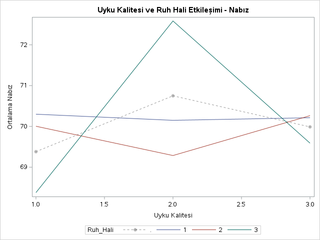

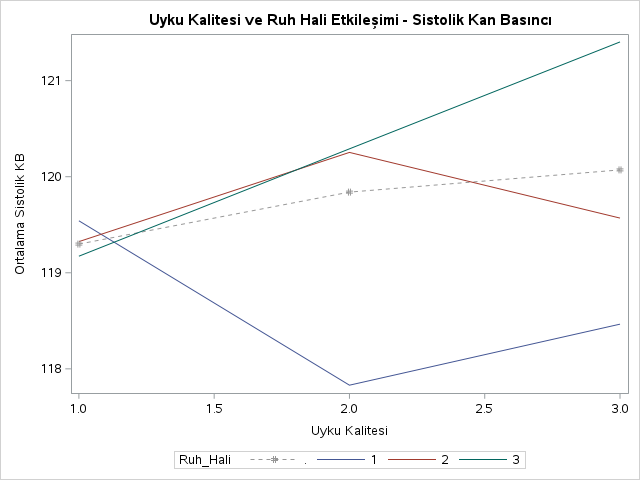

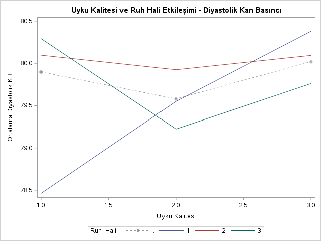

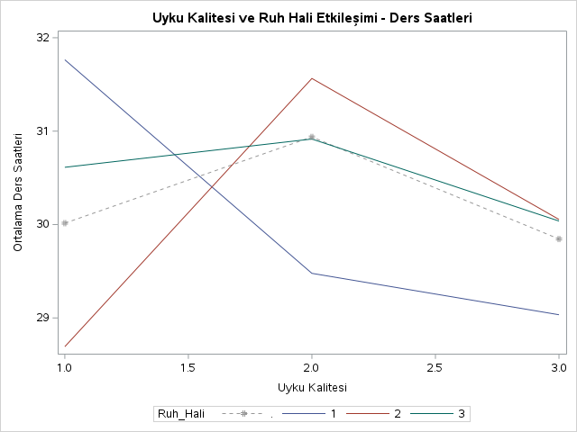

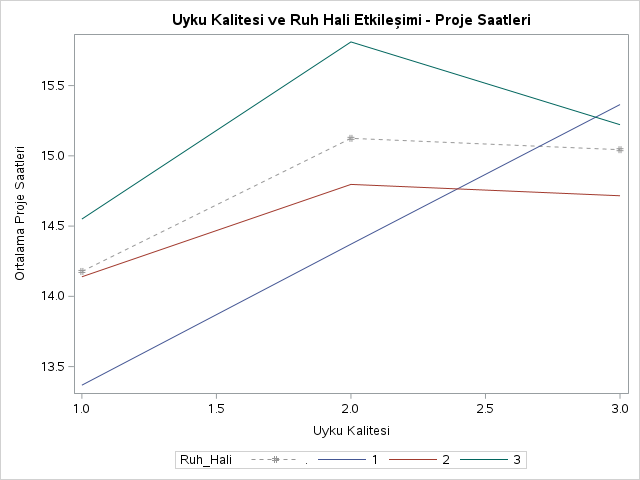